# Project: Identify Customer Segments

In this project, you will apply unsupervised learning techniques to identify segments of the population that form the core customer base for a mail-order sales company in Germany. These segments can then be used to direct marketing campaigns towards audiences that will have the highest expected rate of returns. The data that you will use has been provided by our partners at Bertelsmann Arvato Analytics, and represents a real-life data science task.

This notebook will help you complete this task by providing a framework within which you will perform your analysis steps. In each step of the project, you will see some text describing the subtask that you will perform, followed by one or more code cells for you to complete your work. **Feel free to add additional code and markdown cells as you go along so that you can explore everything in precise chunks.** The code cells provided in the base template will outline only the major tasks, and will usually not be enough to cover all of the minor tasks that comprise it.

It should be noted that while there will be precise guidelines on how you should handle certain tasks in the project, there will also be places where an exact specification is not provided. **There will be times in the project where you will need to make and justify your own decisions on how to treat the data.** These are places where there may not be only one way to handle the data. In real-life tasks, there may be many valid ways to approach an analysis task. One of the most important things you can do is clearly document your approach so that other scientists can understand the decisions you've made.

At the end of most sections, there will be a Markdown cell labeled **Discussion**. In these cells, you will report your findings for the completed section, as well as document the decisions that you made in your approach to each subtask. **Your project will be evaluated not just on the code used to complete the tasks outlined, but also your communication about your observations and conclusions at each stage.**

```python
# import libraries here; add more as necessary
import numpy as np
import pandas as pd
import matplotlib.pyplot as plt
import seaborn as sns
from sklearn.cluster import KMeans


# magic word for producing visualizations in notebook
%matplotlib inline
```

### Step 0: Load the Data

There are four files associated with this project (not including this one):

- `Udacity_AZDIAS_Subset.csv`: Demographics data for the general population of Germany; 891211 persons (rows) x 85 features (columns).
- `Udacity_CUSTOMERS_Subset.csv`: Demographics data for customers of a mail-order company; 191652 persons (rows) x 85 features (columns).
- `Data_Dictionary.md`: Detailed information file about the features in the provided datasets.
- `AZDIAS_Feature_Summary.csv`: Summary of feature attributes for demographics data; 85 features (rows) x 4 columns

Each row of the demographics files represents a single person, but also includes information outside of individuals, including information about their household, building, and neighborhood. You will use this information to cluster the general population into groups with similar demographic properties. Then, you will see how the people in the customers dataset fit into those created clusters. The hope here is that certain clusters are over-represented in the customers data, as compared to the general population; those over-represented clusters will be assumed to be part of the core userbase. This information can then be used for further applications, such as targeting for a marketing campaign.

To start off with, load in the demographics data for the general population into a pandas DataFrame, and do the same for the feature attributes summary. Note for all of the `.csv` data files in this project: they're semicolon (`;`) delimited, so you'll need an additional argument in your [`read_csv()`](https://pandas.pydata.org/pandas-docs/stable/generated/pandas.read_csv.html) call to read in the data properly. Also, considering the size of the main dataset, it may take some time for it to load completely.

Once the dataset is loaded, it's recommended that you take a little bit of time just browsing the general structure of the dataset and feature summary file. You'll be getting deep into the innards of the cleaning in the first major step of the project, so gaining some general familiarity can help you get your bearings.

```python
# Load in the general demographics data.
azdias = pd.read_csv("Udacity_AZDIAS_Subset.csv", sep=";")

# Load in the feature summary file.
feat_info = pd.read_csv("AZDIAS_Feature_Summary.csv", sep=";")
```

```python
# Check the structure of the data after it's loaded (e.g. print the number of
# rows and columns, print the first few rows).
azdias.describe()
```

|  | AGER_TYP | ALTERSKATEGORIE_GROB | ANREDE_KZ | CJT_GESAMTTYP | FINANZ_MINIMALIST | FINANZ_SPARER | FINANZ_VORSORGER | FINANZ_ANLEGER | FINANZ_UNAUFFAELLIGER | FINANZ_HAUSBAUER | ... | PLZ8_ANTG1 | PLZ8_ANTG2 | PLZ8_ANTG3 | PLZ8_ANTG4 | PLZ8_BAUMAX | PLZ8_HHZ | PLZ8_GBZ | ARBEIT | ORTSGR_KLS9 | RELAT_AB |
| --- | --- | --- | --- | --- | --- | --- | --- | --- | --- | --- | --- | --- | --- | --- | --- | --- | --- | --- | --- | --- | --- |
| count | 891221.000000 | 891221.000000 | 891221.000000 | 886367.000000 | 891221.000000 | 891221.000000 | 891221.000000 | 891221.000000 | 891221.000000 | 891221.000000 | ... | 774706.000000 | 774706.000000 | 774706.000000 | 774706.000000 | 774706.000000 | 774706.000000 | 774706.000000 | 794005.000000 | 794005.000000 | 794005.00000 |
| mean | -0.358435 | 2.777398 | 1.522098 | 3.632838 | 3.074528 | 2.821039 | 3.401106 | 3.033328 | 2.874167 | 3.075121 | ... | 2.253330 | 2.801858 | 1.595426 | 0.699166 | 1.943913 | 3.612821 | 3.381087 | 3.167854 | 5.293002 | 3.07222 |
| std | 1.198724 | 1.068775 | 0.499512 | 1.595021 | 1.321055 | 1.464749 | 1.322134 | 1.529603 | 1.486731 | 1.353248 | ... | 0.972008 | 0.920309 | 0.986736 | 0.727137 | 1.459654 | 0.973967 | 1.111598 | 1.002376 | 2.303739 | 1.36298 |
| min | -1.000000 | 1.000000 | 1.000000 | 1.000000 | 1.000000 | 1.000000 | 1.000000 | 1.000000 | 1.000000 | 1.000000 | ... | 0.000000 | 0.000000 | 0.000000 | 0.000000 | 1.000000 | 1.000000 | 1.000000 | 1.000000 | 0.000000 | 1.00000 |
| 25% | -1.000000 | 2.000000 | 1.000000 | 2.000000 | 2.000000 | 1.000000 | 3.000000 | 2.000000 | 2.000000 | 2.000000 | ... | 1.000000 | 2.000000 | 1.000000 | 0.000000 | 1.000000 | 3.000000 | 3.000000 | 3.000000 | 4.000000 | 2.00000 |
| 50% | -1.000000 | 3.000000 | 2.000000 | 4.000000 | 3.000000 | 3.000000 | 3.000000 | 3.000000 | 3.000000 | 3.000000 | ... | 2.000000 | 3.000000 | 2.000000 | 1.000000 | 1.000000 | 4.000000 | 3.000000 | 3.000000 | 5.000000 | 3.00000 |
| 75% | -1.000000 | 4.000000 | 2.000000 | 5.000000 | 4.000000 | 4.000000 | 5.000000 | 5.000000 | 4.000000 | 4.000000 | ... | 3.000000 | 3.000000 | 2.000000 | 1.000000 | 3.000000 | 4.000000 | 4.000000 | 4.000000 | 7.000000 | 4.00000 |
| max | 3.000000 | 9.000000 | 2.000000 | 6.000000 | 5.000000 | 5.000000 | 5.000000 | 5.000000 | 5.000000 | 5.000000 | ... | 4.000000 | 4.000000 | 3.000000 | 2.000000 | 5.000000 | 5.000000 | 5.000000 | 9.000000 | 9.000000 | 9.00000 |

8 rows × 81 columns

```python
azdias.info()
```

```
<class 'pandas.core.frame.DataFrame'>
RangeIndex: 891221 entries, 0 to 891220
Data columns (total 85 columns):
AGER_TYP                 891221 non-null int64
ALTERSKATEGORIE_GROB     891221 non-null int64
ANREDE_KZ                891221 non-null int64
CJT_GESAMTTYP            886367 non-null float64
FINANZ_MINIMALIST        891221 non-null int64
FINANZ_SPARER            891221 non-null int64
FINANZ_VORSORGER         891221 non-null int64
FINANZ_ANLEGER           891221 non-null int64
FINANZ_UNAUFFAELLIGER    891221 non-null int64
FINANZ_HAUSBAUER         891221 non-null int64
FINANZTYP                891221 non-null int64
GEBURTSJAHR              891221 non-null int64
GFK_URLAUBERTYP          886367 non-null float64
GREEN_AVANTGARDE         891221 non-null int64
HEALTH_TYP               891221 non-null int64
LP_LEBENSPHASE_FEIN      886367 non-null float64
LP_LEBENSPHASE_GROB      886367 non-null float64
LP_FAMILIE_FEIN          886367 non-null float64
LP_FAMILIE_GROB          886367 non-null float64
LP_STATUS_FEIN           886367 non-null float64
LP_STATUS_GROB           886367 non-null float64
NATIONALITAET_KZ         891221 non-null int64
PRAEGENDE_JUGENDJAHRE    891221 non-null int64
RETOURTYP_BK_S           886367 non-null float64
SEMIO_SOZ                891221 non-null int64
SEMIO_FAM                891221 non-null int64
SEMIO_REL                891221 non-null int64
SEMIO_MAT                891221 non-null int64
SEMIO_VERT               891221 non-null int64
SEMIO_LUST               891221 non-null int64
SEMIO_ERL                891221 non-null int64
SEMIO_KULT               891221 non-null int64
SEMIO_RAT                891221 non-null int64
SEMIO_KRIT               891221 non-null int64
SEMIO_DOM                891221 non-null int64
SEMIO_KAEM               891221 non-null int64
SEMIO_PFLICHT            891221 non-null int64
```

[output cut: 35 more lines]

```
ONLINE_AFFINITAET        886367 non-null float64
REGIOTYP                 770025 non-null float64
KBA13_ANZAHL_PKW         785421 non-null float64
PLZ8_ANTG1               774706 non-null float64
PLZ8_ANTG2               774706 non-null float64
PLZ8_ANTG3               774706 non-null float64
PLZ8_ANTG4               774706 non-null float64
PLZ8_BAUMAX              774706 non-null float64
PLZ8_HHZ                 774706 non-null float64
PLZ8_GBZ                 774706 non-null float64
ARBEIT                   794005 non-null float64
ORTSGR_KLS9              794005 non-null float64
RELAT_AB                 794005 non-null float64
dtypes: float64(49), int64(32), object(4)
memory usage: 578.0+ MB
```

```python
azdias.head()
```

|  | AGER_TYP | ALTERSKATEGORIE_GROB | ANREDE_KZ | CJT_GESAMTTYP | FINANZ_MINIMALIST | FINANZ_SPARER | FINANZ_VORSORGER | FINANZ_ANLEGER | FINANZ_UNAUFFAELLIGER | FINANZ_HAUSBAUER | ... | PLZ8_ANTG1 | PLZ8_ANTG2 | PLZ8_ANTG3 | PLZ8_ANTG4 | PLZ8_BAUMAX | PLZ8_HHZ | PLZ8_GBZ | ARBEIT | ORTSGR_KLS9 | RELAT_AB |
| --- | --- | --- | --- | --- | --- | --- | --- | --- | --- | --- | --- | --- | --- | --- | --- | --- | --- | --- | --- | --- | --- |
| 0 | -1 | 2 | 1 | 2.0 | 3 | 4 | 3 | 5 | 5 | 3 | ... | NaN | NaN | NaN | NaN | NaN | NaN | NaN | NaN | NaN | NaN |
| 1 | -1 | 1 | 2 | 5.0 | 1 | 5 | 2 | 5 | 4 | 5 | ... | 2.0 | 3.0 | 2.0 | 1.0 | 1.0 | 5.0 | 4.0 | 3.0 | 5.0 | 4.0 |
| 2 | -1 | 3 | 2 | 3.0 | 1 | 4 | 1 | 2 | 3 | 5 | ... | 3.0 | 3.0 | 1.0 | 0.0 | 1.0 | 4.0 | 4.0 | 3.0 | 5.0 | 2.0 |
| 3 | 2 | 4 | 2 | 2.0 | 4 | 2 | 5 | 2 | 1 | 2 | ... | 2.0 | 2.0 | 2.0 | 0.0 | 1.0 | 3.0 | 4.0 | 2.0 | 3.0 | 3.0 |
| 4 | -1 | 3 | 1 | 5.0 | 4 | 3 | 4 | 1 | 3 | 2 | ... | 2.0 | 4.0 | 2.0 | 1.0 | 2.0 | 3.0 | 3.0 | 4.0 | 6.0 | 5.0 |

5 rows × 85 columns

```python
feat_info.describe()
```

|  | attribute | information_level | type | missing_or_unknown |
| --- | --- | --- | --- | --- |
| count | 85 | 85 | 85 | 85 |
| unique | 85 | 9 | 5 | 9 |
| top | PLZ8_GBZ | person | ordinal | [-1] |
| freq | 1 | 43 | 49 | 26 |

```python
feat_info.info()
```

```
<class 'pandas.core.frame.DataFrame'>
RangeIndex: 85 entries, 0 to 84
Data columns (total 4 columns):
attribute             85 non-null object
information_level     85 non-null object
type                  85 non-null object
missing_or_unknown    85 non-null object
dtypes: object(4)
memory usage: 2.8+ KB
```

```python
feat_info.head()
```

|  | attribute | information_level | type | missing_or_unknown |
| --- | --- | --- | --- | --- |
| 0 | AGER_TYP | person | categorical | [-1,0] |
| 1 | ALTERSKATEGORIE_GROB | person | ordinal | [-1,0,9] |
| 2 | ANREDE_KZ | person | categorical | [-1,0] |
| 3 | CJT_GESAMTTYP | person | categorical | [0] |
| 4 | FINANZ_MINIMALIST | person | ordinal | [-1] |

> **Tip**: Add additional cells to keep everything in reasonably-sized chunks! Keyboard shortcut `esc --> a` (press escape to enter command mode, then press the 'A' key) adds a new cell before the active cell, and `esc --> b` adds a new cell after the active cell. If you need to convert an active cell to a markdown cell, use `esc --> m` and to convert to a code cell, use `esc --> y`.

## Step 1: Preprocessing

### Step 1.1: Assess Missing Data

The feature summary file contains a summary of properties for each demographics data column. You will use this file to help you make cleaning decisions during this stage of the project. First of all, you should assess the demographics data in terms of missing data. Pay attention to the following points as you perform your analysis, and take notes on what you observe. Make sure that you fill in the **Discussion** cell with your findings and decisions at the end of each step that has one!

#### Step 1.1.1: Convert Missing Value Codes to NaNs

The fourth column of the feature attributes summary (loaded in above as `feat_info`) documents the codes from the data dictionary that indicate missing or unknown data. While the file encodes this as a list (e.g. `[-1,0]`), this will get read in as a string object. You'll need to do a little bit of parsing to make use of it to identify and clean the data. Convert data that matches a 'missing' or 'unknown' value code into a numpy NaN value. You might want to see how much data takes on a 'missing' or 'unknown' code, and how much data is naturally missing, as a point of interest.

**As one more reminder, you are encouraged to add additional cells to break up your analysis into manageable chunks.**

```python
# Identify missing or unknown data values and convert them to NaNs.
from copy import deepcopy
# create a copy of dataframe for data cleaning
azdidas_copy = deepcopy(azdias)
```

```python
# iterate trough columns of dataframes and mark missing values
# as NaN based on the feat_info document
total_sample_number = len(azdidas_copy)
total_missing_values = 0
percentage_nan_data_per_attribute = dict()

for col in azdidas_copy.columns:

    missing_unknow_per_attribute = eval(feat_info["missing_or_unknown"][feat_info["attribute"] == col].values[0])

    if len(missing_unknow_per_attribute) > 0:
        # when calling eval, the whole list is
        # is parsed as string, therefore the string X'ses
        # are interpreted as variables and not strings
        X="X"
        XX="XX"
        x="x"

        azdidas_copy[col].replace(to_replace=missing_unknow_per_attribute, value=np.nan, inplace=True)

    total_missing_unknow_per_attribute = azdidas_copy[col].isna().sum()
    percentage_missing_unknow_per_attribute = total_missing_unknow_per_attribute / total_sample_number

    percentage_nan_data_per_attribute[col] = percentage_missing_unknow_per_attribute


    total_missing_values+=total_missing_unknow_per_attribute

    print("Total number of missing values for attribute <{}>: {}".format(col,total_missing_unknow_per_attribute))
    print("Percentage of missing values for attribute <{}>: {} %".format(col,percentage_missing_unknow_per_attribute))
    print()

print("#######################################")
print("Total number of missing values: {}".format(total_missing_values))
```

```
Total number of missing values for attribute <AGER_TYP>: 685843
Percentage of missing values for attribute <AGER_TYP>: 0.7695543529607134 %

Total number of missing values for attribute <ALTERSKATEGORIE_GROB>: 2881
Percentage of missing values for attribute <ALTERSKATEGORIE_GROB>: 0.0032326437550282143 %

Total number of missing values for attribute <ANREDE_KZ>: 0
Percentage of missing values for attribute <ANREDE_KZ>: 0.0 %

Total number of missing values for attribute <CJT_GESAMTTYP>: 4854
Percentage of missing values for attribute <CJT_GESAMTTYP>: 0.005446460529992 %

Total number of missing values for attribute <FINANZ_MINIMALIST>: 0
Percentage of missing values for attribute <FINANZ_MINIMALIST>: 0.0 %

Total number of missing values for attribute <FINANZ_SPARER>: 0
Percentage of missing values for attribute <FINANZ_SPARER>: 0.0 %

Total number of missing values for attribute <FINANZ_VORSORGER>: 0
Percentage of missing values for attribute <FINANZ_VORSORGER>: 0.0 %

Total number of missing values for attribute <FINANZ_ANLEGER>: 0
Percentage of missing values for attribute <FINANZ_ANLEGER>: 0.0 %

Total number of missing values for attribute <FINANZ_UNAUFFAELLIGER>: 0
Percentage of missing values for attribute <FINANZ_UNAUFFAELLIGER>: 0.0 %

Total number of missing values for attribute <FINANZ_HAUSBAUER>: 0
Percentage of missing values for attribute <FINANZ_HAUSBAUER>: 0.0 %

Total number of missing values for attribute <FINANZTYP>: 0
Percentage of missing values for attribute <FINANZTYP>: 0.0 %

Total number of missing values for attribute <GEBURTSJAHR>: 392318
Percentage of missing values for attribute <GEBURTSJAHR>: 0.4402028228688507 %

Total number of missing values for attribute <GFK_URLAUBERTYP>: 4854
Percentage of missing values for attribute <GFK_URLAUBERTYP>: 0.005446460529992 %

Total number of missing values for attribute <GREEN_AVANTGARDE>: 0
```

[output cut: 202 more lines]

```

Total number of missing values for attribute <PLZ8_GBZ>: 116515
Percentage of missing values for attribute <PLZ8_GBZ>: 0.13073637178657146 %

Total number of missing values for attribute <ARBEIT>: 97375
Percentage of missing values for attribute <ARBEIT>: 0.10926021716274639 %

Total number of missing values for attribute <ORTSGR_KLS9>: 97274
Percentage of missing values for attribute <ORTSGR_KLS9>: 0.1091468894920564 %

Total number of missing values for attribute <RELAT_AB>: 97375
Percentage of missing values for attribute <RELAT_AB>: 0.10926021716274639 %

#######################################
Total number of missing values: 8373929
```

#### Step 1.1.2: Assess Missing Data in Each Column

How much missing data is present in each column? There are a few columns that are outliers in terms of the proportion of values that are missing. You will want to use matplotlib's [`hist()`](https://matplotlib.org/api/_as_gen/matplotlib.pyplot.hist.html) function to visualize the distribution of missing value counts to find these columns. Identify and document these columns. While some of these columns might have justifications for keeping or re-encoding the data, for this project you should just remove them from the dataframe. (Feel free to make remarks about these outlier columns in the discussion, however!)

For the remaining features, are there any patterns in which columns have, or share, missing data?

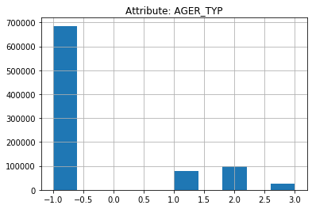

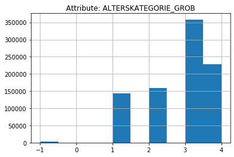

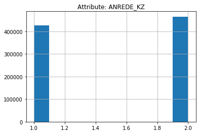

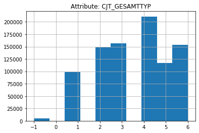

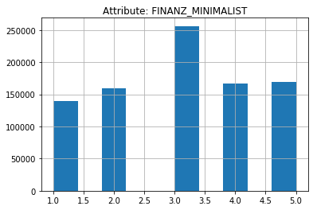

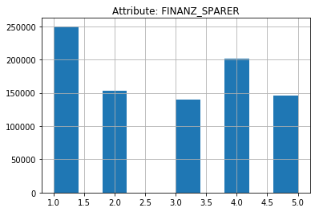

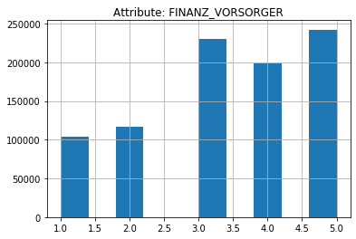

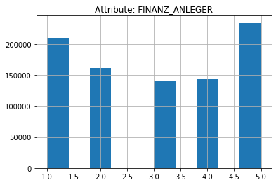

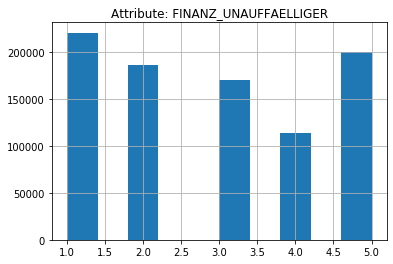

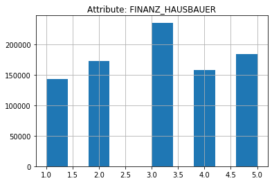

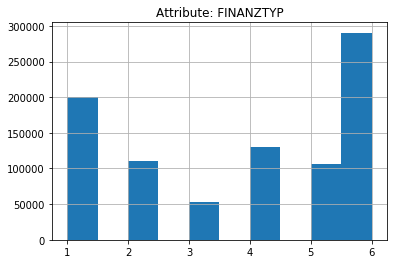

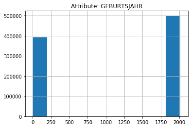

[73 more figures not shown]

```python
# Perform an assessment of how much missing data there is in each column of the
# dataset.
threshold = 0.3
high_percentage_of_missing_data = []


for col in azdidas_copy.columns:

    if azdidas_copy[col].dtype.kind is not "O":
        # fill nas with -1 (all attributes are encodes as postive integers)
        tmp_col = azdidas_copy[col].fillna(-1)

    elif azdidas_copy[col].dtype.kind is "O":
        # fill nas with -1 (all attributes are encodes as postive integers)
        tmp_col = azdidas_copy[col].fillna("-1")

    subplot = tmp_col.hist()
    plt.title("Attribute: {}".format(col))
    plt.show()

    # I will remove the colums based on the percentage of missing data (see discussion)
    # the percentage of missing data per attribute has been previously calculated (step 1.1.1)
    if percentage_nan_data_per_attribute[col] >= threshold:
        high_percentage_of_missing_data.append(col)
```

```python
# attributes with more than 40 % of missing data
high_percentage_of_missing_data
```

```
['AGER_TYP',
 'GEBURTSJAHR',
 'TITEL_KZ',
 'ALTER_HH',
 'KK_KUNDENTYP',
 'KBA05_BAUMAX']
```

```python
percentage_nan_data_per_attribute
```

```
{'AGER_TYP': 0.7695543529607134,
 'ALTERSKATEGORIE_GROB': 0.0032326437550282143,
 'ANREDE_KZ': 0.0,
 'CJT_GESAMTTYP': 0.005446460529992,
 'FINANZ_MINIMALIST': 0.0,
 'FINANZ_SPARER': 0.0,
 'FINANZ_VORSORGER': 0.0,
 'FINANZ_ANLEGER': 0.0,
 'FINANZ_UNAUFFAELLIGER': 0.0,
 'FINANZ_HAUSBAUER': 0.0,
 'FINANZTYP': 0.0,
 'GEBURTSJAHR': 0.4402028228688507,
 'GFK_URLAUBERTYP': 0.005446460529992,
 'GREEN_AVANTGARDE': 0.0,
 'HEALTH_TYP': 0.12476815514894735,
 'LP_LEBENSPHASE_FEIN': 0.10954858559212585,
 'LP_LEBENSPHASE_GROB': 0.10611509378706292,
 'LP_FAMILIE_FEIN': 0.08728699166648901,
 'LP_FAMILIE_GROB': 0.08728699166648901,
 'LP_STATUS_FEIN': 0.005446460529992,
 'LP_STATUS_GROB': 0.005446460529992,
 'NATIONALITAET_KZ': 0.12153551139391913,
 'PRAEGENDE_JUGENDJAHRE': 0.12136608091595687,
 'RETOURTYP_BK_S': 0.005446460529992,
 'SEMIO_SOZ': 0.0,
 'SEMIO_FAM': 0.0,
 'SEMIO_REL': 0.0,
 'SEMIO_MAT': 0.0,
 'SEMIO_VERT': 0.0,
 'SEMIO_LUST': 0.0,
 'SEMIO_ERL': 0.0,
 'SEMIO_KULT': 0.0,
 'SEMIO_RAT': 0.0,
 'SEMIO_KRIT': 0.0,
 'SEMIO_DOM': 0.0,
 'SEMIO_KAEM': 0.0,
 'SEMIO_PFLICHT': 0.0,
 'SEMIO_TRADV': 0.0,
 'SHOPPER_TYP': 0.12476815514894735,
 'SOHO_KZ': 0.08247000463409188,
```

[output cut: 30 more lines]

```
 'KKK': 0.17735668257368262,
 'MOBI_REGIO': 0.14959701353536328,
 'ONLINE_AFFINITAET': 0.005446460529992,
 'REGIOTYP': 0.17735668257368262,
 'KBA13_ANZAHL_PKW': 0.11871354018812394,
 'PLZ8_ANTG1': 0.13073637178657146,
 'PLZ8_ANTG2': 0.13073637178657146,
 'PLZ8_ANTG3': 0.13073637178657146,
 'PLZ8_ANTG4': 0.13073637178657146,
 'PLZ8_BAUMAX': 0.13073637178657146,
 'PLZ8_HHZ': 0.13073637178657146,
 'PLZ8_GBZ': 0.13073637178657146,
 'ARBEIT': 0.10926021716274639,
 'ORTSGR_KLS9': 0.1091468894920564,
 'RELAT_AB': 0.10926021716274639}
```

```python
# Investigate patterns in the amount of missing data in each column.
# Based on the stored percentages of missing values, the missing values
attributes_with_missing_data = {col:percentage_nan_data_per_attribute[col] for col in azdidas_copy.columns if percentage_nan_data_per_attribute[col] > 0.0}
attributes_with_missing_data
```

```
{'AGER_TYP': 0.7695543529607134,
 'ALTERSKATEGORIE_GROB': 0.0032326437550282143,
 'CJT_GESAMTTYP': 0.005446460529992,
 'GEBURTSJAHR': 0.4402028228688507,
 'GFK_URLAUBERTYP': 0.005446460529992,
 'HEALTH_TYP': 0.12476815514894735,
 'LP_LEBENSPHASE_FEIN': 0.10954858559212585,
 'LP_LEBENSPHASE_GROB': 0.10611509378706292,
 'LP_FAMILIE_FEIN': 0.08728699166648901,
 'LP_FAMILIE_GROB': 0.08728699166648901,
 'LP_STATUS_FEIN': 0.005446460529992,
 'LP_STATUS_GROB': 0.005446460529992,
 'NATIONALITAET_KZ': 0.12153551139391913,
 'PRAEGENDE_JUGENDJAHRE': 0.12136608091595687,
 'RETOURTYP_BK_S': 0.005446460529992,
 'SHOPPER_TYP': 0.12476815514894735,
 'SOHO_KZ': 0.08247000463409188,
 'TITEL_KZ': 0.9975763587258379,
 'VERS_TYP': 0.12476815514894735,
 'ALTER_HH': 0.34813699407890975,
 'ANZ_PERSONEN': 0.08247000463409188,
 'ANZ_TITEL': 0.08247000463409188,
 'HH_EINKOMMEN_SCORE': 0.020587486156632306,
 'KK_KUNDENTYP': 0.6559674873011295,
 'W_KEIT_KIND_HH': 0.16605084485217472,
 'WOHNDAUER_2008': 0.08247000463409188,
 'ANZ_HAUSHALTE_AKTIV': 0.11176913470396231,
 'ANZ_HH_TITEL': 0.10884842255736793,
 'GEBAEUDETYP': 0.10451728583594866,
 'KONSUMNAEHE': 0.08299737102245122,
 'MIN_GEBAEUDEJAHR': 0.10451728583594866,
 'OST_WEST_KZ': 0.10451728583594866,
 'WOHNLAGE': 0.10451728583594866,
 'CAMEO_DEUG_2015': 0.11147852216229195,
 'CAMEO_DEU_2015': 0.11147852216229195,
 'CAMEO_INTL_2015': 0.11147852216229195,
 'KBA05_ANTG1': 0.14959701353536328,
 'KBA05_ANTG2': 0.14959701353536328,
 'KBA05_ANTG3': 0.14959701353536328,
 'KBA05_ANTG4': 0.14959701353536328,
 'KBA05_BAUMAX': 0.5346866826522265,
 'KBA05_GBZ': 0.14959701353536328,
 'BALLRAUM': 0.10518154307405234,
 'EWDICHTE': 0.10518154307405234,
 'INNENSTADT': 0.10518154307405234,
 'GEBAEUDETYP_RASTER': 0.10452514022896678,
 'KKK': 0.17735668257368262,
 'MOBI_REGIO': 0.14959701353536328,
 'ONLINE_AFFINITAET': 0.005446460529992,
 'REGIOTYP': 0.17735668257368262,
 'KBA13_ANZAHL_PKW': 0.11871354018812394,
 'PLZ8_ANTG1': 0.13073637178657146,
 'PLZ8_ANTG2': 0.13073637178657146,
 'PLZ8_ANTG3': 0.13073637178657146,
 'PLZ8_ANTG4': 0.13073637178657146,
 'PLZ8_BAUMAX': 0.13073637178657146,
 'PLZ8_HHZ': 0.13073637178657146,
 'PLZ8_GBZ': 0.13073637178657146,
 'ARBEIT': 0.10926021716274639,
 'ORTSGR_KLS9': 0.1091468894920564,
 'RELAT_AB': 0.10926021716274639}
```

```python
print ("{} of {} attributes contain missing data.".format(len(attributes_with_missing_data), len(azdidas_copy.columns)))
```

```
61 of 85 attributes contain missing data.
```

```python
attributes_with_missing_data_sorted = sorted(attributes_with_missing_data.items(), key=lambda x: x[1],reverse=True)
attributes_with_missing_data_sorted
```

```
[('TITEL_KZ', 0.9975763587258379),
 ('AGER_TYP', 0.7695543529607134),
 ('KK_KUNDENTYP', 0.6559674873011295),
 ('KBA05_BAUMAX', 0.5346866826522265),
 ('GEBURTSJAHR', 0.4402028228688507),
 ('ALTER_HH', 0.34813699407890975),
 ('KKK', 0.17735668257368262),
 ('REGIOTYP', 0.17735668257368262),
 ('W_KEIT_KIND_HH', 0.16605084485217472),
 ('KBA05_ANTG1', 0.14959701353536328),
 ('KBA05_ANTG2', 0.14959701353536328),
 ('KBA05_ANTG3', 0.14959701353536328),
 ('KBA05_ANTG4', 0.14959701353536328),
 ('KBA05_GBZ', 0.14959701353536328),
 ('MOBI_REGIO', 0.14959701353536328),
 ('PLZ8_ANTG1', 0.13073637178657146),
 ('PLZ8_ANTG2', 0.13073637178657146),
 ('PLZ8_ANTG3', 0.13073637178657146),
 ('PLZ8_ANTG4', 0.13073637178657146),
 ('PLZ8_BAUMAX', 0.13073637178657146),
 ('PLZ8_HHZ', 0.13073637178657146),
 ('PLZ8_GBZ', 0.13073637178657146),
 ('HEALTH_TYP', 0.12476815514894735),
 ('SHOPPER_TYP', 0.12476815514894735),
 ('VERS_TYP', 0.12476815514894735),
 ('NATIONALITAET_KZ', 0.12153551139391913),
 ('PRAEGENDE_JUGENDJAHRE', 0.12136608091595687),
 ('KBA13_ANZAHL_PKW', 0.11871354018812394),
 ('ANZ_HAUSHALTE_AKTIV', 0.11176913470396231),
 ('CAMEO_DEUG_2015', 0.11147852216229195),
 ('CAMEO_DEU_2015', 0.11147852216229195),
 ('CAMEO_INTL_2015', 0.11147852216229195),
 ('LP_LEBENSPHASE_FEIN', 0.10954858559212585),
 ('ARBEIT', 0.10926021716274639),
 ('RELAT_AB', 0.10926021716274639),
 ('ORTSGR_KLS9', 0.1091468894920564),
 ('ANZ_HH_TITEL', 0.10884842255736793),
 ('LP_LEBENSPHASE_GROB', 0.10611509378706292),
 ('BALLRAUM', 0.10518154307405234),
 ('EWDICHTE', 0.10518154307405234),
 ('INNENSTADT', 0.10518154307405234),
 ('GEBAEUDETYP_RASTER', 0.10452514022896678),
 ('GEBAEUDETYP', 0.10451728583594866),
 ('MIN_GEBAEUDEJAHR', 0.10451728583594866),
 ('OST_WEST_KZ', 0.10451728583594866),
 ('WOHNLAGE', 0.10451728583594866),
 ('LP_FAMILIE_FEIN', 0.08728699166648901),
 ('LP_FAMILIE_GROB', 0.08728699166648901),
 ('KONSUMNAEHE', 0.08299737102245122),
 ('SOHO_KZ', 0.08247000463409188),
 ('ANZ_PERSONEN', 0.08247000463409188),
 ('ANZ_TITEL', 0.08247000463409188),
 ('WOHNDAUER_2008', 0.08247000463409188),
 ('HH_EINKOMMEN_SCORE', 0.020587486156632306),
 ('CJT_GESAMTTYP', 0.005446460529992),
 ('GFK_URLAUBERTYP', 0.005446460529992),
 ('LP_STATUS_FEIN', 0.005446460529992),
 ('LP_STATUS_GROB', 0.005446460529992),
 ('RETOURTYP_BK_S', 0.005446460529992),
 ('ONLINE_AFFINITAET', 0.005446460529992),
 ('ALTERSKATEGORIE_GROB', 0.0032326437550282143)]
```

```python
# print attribute
for attribute,nan_percent in attributes_with_missing_data_sorted:
    information_level = feat_info[feat_info["attribute"] == attribute]["information_level"].values[0]
    print("Attribute: {} - Information level: {} - Missing: {} %".format(attribute,information_level,nan_percent*100))
    print()
```

```
Attribute: TITEL_KZ - Information level: person - Missing: 99.75763587258379 %

Attribute: AGER_TYP - Information level: person - Missing: 76.95543529607134 %

Attribute: KK_KUNDENTYP - Information level: household - Missing: 65.59674873011295 %

Attribute: KBA05_BAUMAX - Information level: microcell_rr3 - Missing: 53.468668265222654 %

Attribute: GEBURTSJAHR - Information level: person - Missing: 44.02028228688507 %

Attribute: ALTER_HH - Information level: household - Missing: 34.81369940789097 %

Attribute: KKK - Information level: region_rr1 - Missing: 17.73566825736826 %

Attribute: REGIOTYP - Information level: region_rr1 - Missing: 17.73566825736826 %

Attribute: W_KEIT_KIND_HH - Information level: household - Missing: 16.60508448521747 %

Attribute: KBA05_ANTG1 - Information level: microcell_rr3 - Missing: 14.959701353536328 %

Attribute: KBA05_ANTG2 - Information level: microcell_rr3 - Missing: 14.959701353536328 %

Attribute: KBA05_ANTG3 - Information level: microcell_rr3 - Missing: 14.959701353536328 %

Attribute: KBA05_ANTG4 - Information level: microcell_rr3 - Missing: 14.959701353536328 %

Attribute: KBA05_GBZ - Information level: microcell_rr3 - Missing: 14.959701353536328 %

Attribute: MOBI_REGIO - Information level: region_rr1 - Missing: 14.959701353536328 %

Attribute: PLZ8_ANTG1 - Information level: macrocell_plz8 - Missing: 13.073637178657146 %

Attribute: PLZ8_ANTG2 - Information level: macrocell_plz8 - Missing: 13.073637178657146 %

Attribute: PLZ8_ANTG3 - Information level: macrocell_plz8 - Missing: 13.073637178657146 %

Attribute: PLZ8_ANTG4 - Information level: macrocell_plz8 - Missing: 13.073637178657146 %

Attribute: PLZ8_BAUMAX - Information level: macrocell_plz8 - Missing: 13.073637178657146 %

```

[output cut: 66 more lines]

```
Attribute: HH_EINKOMMEN_SCORE - Information level: household - Missing: 2.0587486156632306 %

Attribute: CJT_GESAMTTYP - Information level: person - Missing: 0.5446460529992 %

Attribute: GFK_URLAUBERTYP - Information level: person - Missing: 0.5446460529992 %

Attribute: LP_STATUS_FEIN - Information level: person - Missing: 0.5446460529992 %

Attribute: LP_STATUS_GROB - Information level: person - Missing: 0.5446460529992 %

Attribute: RETOURTYP_BK_S - Information level: person - Missing: 0.5446460529992 %

Attribute: ONLINE_AFFINITAET - Information level: region_rr1 - Missing: 0.5446460529992 %

Attribute: ALTERSKATEGORIE_GROB - Information level: person - Missing: 0.32326437550282144 %
```

```python
# Remove the outlier columns from the dataset. (You'll perform other data
# engineering tasks such as re-encoding and imputation later.)
azdidas_copy_cols_dropped = azdidas_copy.drop(columns=high_percentage_of_missing_data)
```

```python
pd.unique(azdidas_copy["CAMEO_DEU_2015"])
```

```
array([nan, '8A', '4C', '2A', '6B', '8C', '4A', '2D', '1A', '1E', '9D',
       '5C', '8B', '7A', '5D', '9E', '9B', '1B', '3D', '4E', '4B', '3C',
       '5A', '7B', '9A', '6D', '6E', '2C', '7C', '9C', '7D', '5E', '1D',
       '8D', '6C', '6A', '5B', '4D', '3A', '2B', '7E', '3B', '6F', '5F',
       '1C'], dtype=object)
```

## Discussion

I have chosen a threshold of **30 %** for the maximal percentage of data that can be missing for an attribute, before removing the attribute from further analysis.

Most of these attributes encode direct personal information (e.g. gender in TITEL_KZ or the year of birth in GEBURTSJAHR or ALTER_HH) or information that relates to a person's living conditions (KBA05_BAUMAX), personal experiences (AGER_TYP) and attitudes (KK_KUNDENTYP). As most of this information is especially protected under current German and European law, this information is more unlikely to be present in public datasets. Moreover, from my experience as a German, Germans tend to be more unwilling to share such personal information than citizens of other nations and cultures. Therefore, one might hypothize two main reasons

1. The person did not want to share this type of information with the interviewer
2. The data has been previously anonymized, so that the information was missing, when data of different public data sources for this dataset have been aggregated

## Discussion

I have sorted the columns according to the percentage of missing values. When looking through the sorted list, it became quite clear, that there are a number of columns that share the same or roughly the same percentage of missing data. I have grouped these attribute columns above.

One might reason, that these overlapping missing values can be explained by their relation to each other, e.g. the attributes ARBEIT and RELAT_AB relate to each other, as ARBEIT encodes the share of unemployment in a community, whereas RELAT_ARBEIT encodes the share of unemployment in the county in which community is contained. Therefore, it is reasonable to assume that these features are (highly) correlated to each other. This is likely also true for the features in the "groups" PLZ8* KBA05*, CAMEO*, KKK+REGIOTYP, GEBAEUDETYP* etc.

Moreover, it is observable, that most of these features also share the same information level.

#### Step 1.1.3: Assess Missing Data in Each Row

Now, you'll perform a similar assessment for the rows of the dataset. How much data is missing in each row? As with the columns, you should see some groups of points that have a very different numbers of missing values. Divide the data into two subsets: one for data points that are above some threshold for missing values, and a second subset for points below that threshold.

In order to know what to do with the outlier rows, we should see if the distribution of data values on columns that are not missing data (or are missing very little data) are similar or different between the two groups. Select at least five of these columns and compare the distribution of values.

- You can use seaborn's [`countplot()`](https://seaborn.pydata.org/generated/seaborn.countplot.html) function to create a bar chart of code frequencies and matplotlib's [`subplot()`](https://matplotlib.org/api/_as_gen/matplotlib.pyplot.subplot.html) function to put bar charts for the two subplots side by side.
- To reduce repeated code, you might want to write a function that can perform this comparison, taking as one of its arguments a column to be compared.

Depending on what you observe in your comparison, this will have implications on how you approach your conclusions later in the analysis. If the distributions of non-missing features look similar between the data with many missing values and the data with few or no missing values, then we could argue that simply dropping those points from the analysis won't present a major issue. On the other hand, if the data with many missing values looks very different from the data with few or no missing values, then we should make a note on those data as special. We'll revisit these data later on. **Either way, you should continue your analysis for now using just the subset of the data with few or no missing values.**

```python
# How much data is missing in each row of the dataset?
rows_with_missing_data = azdidas_copy_cols_dropped.isnull().sum(axis=1)
rows_with_missing_data
```

```
0         43
1          0
2          0
3          7
4          0
          ..
891216     3
891217     4
891218     5
891219     0
891220     0
Length: 891221, dtype: int64
```

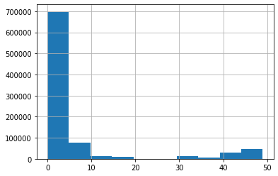

```python
rows_with_missing_data.hist()
```

The histogram shows that the data can be broken down into two groups:

1. The majority of the row data contains 10 or less missing values
2. The minority of the row data contains 10 ore more missing values

```python
# Write code to divide the data into two subsets based on the number of missing
# values in each row.
azdidas_copy_cols_dropped_subset_minor = azdidas_copy_cols_dropped[rows_with_missing_data > 10]
azdidas_copy_cols_dropped_subset_major = azdidas_copy_cols_dropped[rows_with_missing_data <= 10]

print("Number of rows with less or equal than 10 missing values: {}".format(len(azdidas_copy_cols_dropped_subset_major)))
print("Number of rows with more than 10 missing values: {}".format(len(azdidas_copy_cols_dropped_subset_minor)))

print("Percentage of rows with less or equal than 10 missing values: {}".format(len(azdidas_copy_cols_dropped_subset_major) / len(azdidas_copy_cols_dropped)))
print("Percentage of of rows with more than 10 missing values: {}".format(len(azdidas_copy_cols_dropped_subset_minor) / len(azdidas_copy_cols_dropped)))
```

```
Number of rows with less or equal than 10 missing values: 780153
Number of rows with more than 10 missing values: 111068
Percentage of rows with less or equal than 10 missing values: 0.8753754680376696
Percentage of of rows with more than 10 missing values: 0.12462453196233034
```

```python
# Compare the distribution of values for at least five columns where there are
# no or few missing values, between the two subsets.
cols_few_missing = []

for col in azdidas_copy_cols_dropped.columns:

    missing_values = azdidas_copy_cols_dropped[col].isna().sum()
    if missing_values <= 10:
        cols_few_missing.append(col)

import random
random.seed(42)

five_cols_few_missing = []

while len(five_cols_few_missing) != 5:
    col_name = random.choice(cols_few_missing)

    if col_name in five_cols_few_missing:
        pass
    else:
        five_cols_few_missing.append(col_name)

five_cols_few_missing
```

```
['SEMIO_KAEM', 'FINANZ_VORSORGER', 'ANREDE_KZ', 'ZABEOTYP', 'GREEN_AVANTGARDE']
```

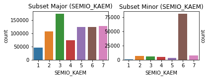

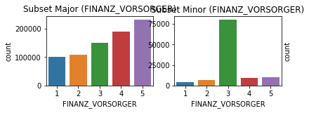

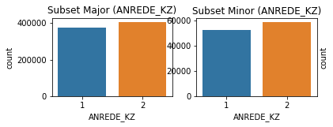

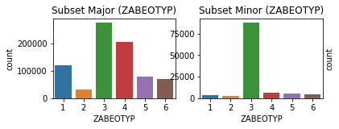

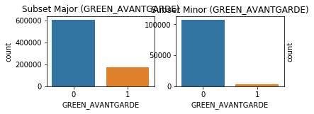

```python
for col in five_cols_few_missing:
    ax = plt.subplot(221)
    plt.title("Subset Major ({})".format(col))
    sns.countplot(azdidas_copy_cols_dropped_subset_major[col])

    ax = plt.subplot(222)
    plt.title("Subset Minor ({})".format(col))
    ax.yaxis.set_label_position("right")
    sns.countplot(azdidas_copy_cols_dropped_subset_minor[col])
    plt.show()
```

#### Discussion 1.1.3: Assess Missing Data in Each Row

The differences between the data with lots and few of missing data are discussed below. Overall, the distribution of the five randomly selected features seems to be more skewed for the data with missing values than for the data with no or few missing values, although there seem to be some exceptions to this general trend (see below).

##### SEMIO_KAEM

###### major subset (few outliners)

The subset is roughly evenly distributed, with the most data for the feature level 3 and fewer data for the levels 1 and 4.

##### FINANZ_VORSORGER

###### major subset (few outliners)

The subset is right-skewed towards the last feature level encoded as 5.

###### minor subset (many outliners)

The subset is highly skewed for the feature level encoded as 3 compared to the major subset, the other feature levels are hardly present in this subset.

##### ANREDE_KZ

###### major subset (few outliners)

The subset is roughly evenly distributed between the features encoding gender.

###### minor subset (many outliners)

The subset is roughly evenly distributed between the features encoding gender.

##### ZABEOTYP

###### major subset (few outliners)

The subset is roughly normally distributed.

###### minor subset (many outliners)

The subset is highly skewed for the feature level 3, the other values are hardly present in this subset (compared to the major subset).

##### GREEN_AVANTGARDE

###### major subset (few outliners)

The subset is unevenly distributed and highly skewed for the feature level 0.

###### minor subset (many outliners)

The subset is unevenly distributed and highly skewed for the feature level 0, even more than for the major subset.

### Step 1.2: Select and Re-Encode Features

Checking for missing data isn't the only way in which you can prepare a dataset for analysis. Since the unsupervised learning techniques to be used will only work on data that is encoded numerically, you need to make a few encoding changes or additional assumptions to be able to make progress. In addition, while almost all of the values in the dataset are encoded using numbers, not all of them represent numeric values. Check the third column of the feature summary (`feat_info`) for a summary of types of measurement.

- For numeric and interval data, these features can be kept without changes.
- Most of the variables in the dataset are ordinal in nature. While ordinal values may technically be non-linear in spacing, make the simplifying assumption that the ordinal variables can be treated as being interval in nature (that is, kept without any changes).
- Special handling may be necessary for the remaining two variable types: categorical, and 'mixed'.

In the first two parts of this sub-step, you will perform an investigation of the categorical and mixed-type features and make a decision on each of them, whether you will keep, drop, or re-encode each. Then, in the last part, you will create a new data frame with only the selected and engineered columns.

Data wrangling is often the trickiest part of the data analysis process, and there's a lot of it to be done here. But stick with it: once you're done with this step, you'll be ready to get to the machine learning parts of the project!

```python
pd.unique(feat_info["type"])
```

```
array(['categorical', 'ordinal', 'numeric', 'mixed', 'interval'],
      dtype=object)
```

```python
# How many features are there of each data type?
numeric = []
ordinal = []
categorical = []
mixed = []

for col in azdidas_copy_cols_dropped:
    feature_type = feat_info[feat_info["attribute"] == col]["type"].values[0]

    if feature_type == 'categorical':
        categorical.append(col)
    elif feature_type == 'numeric':
        numeric.append(col)
    elif feature_type in ['ordinal', 'interval']:
        ordinal.append(col)
    elif feature_type == 'mixed':
        mixed.append(col)


print("Number of numeric features: {}".format(len(numeric)))
print("Number of ordinal / interval features: {}".format(len(ordinal)))
print("Number of categorical features: {}".format(len(categorical)))
print("Number of mixed features: {}".format(len(mixed)))
```

```
Number of numeric features: 6
Number of ordinal / interval features: 49
Number of categorical features: 18
Number of mixed features: 6
```

#### Step 1.2.1: Re-Encode Categorical Features

For categorical data, you would ordinarily need to encode the levels as dummy variables. Depending on the number of categories, perform one of the following:

- For binary (two-level) categoricals that take numeric values, you can keep them without needing to do anything.
- There is one binary variable that takes on non-numeric values. For this one, you need to re-encode the values as numbers or create a dummy variable.
- For multi-level categoricals (three or more values), you can choose to encode the values using multiple dummy variables (e.g. via [OneHotEncoder](http://scikit-learn.org/stable/modules/generated/sklearn.preprocessing.OneHotEncoder.html)), or (to keep things straightforward) just drop them from the analysis. As always, document your choices in the Discussion section.

```python
# Assess categorical variables: which are binary, which are multi-level, and
# which one needs to be re-encoded?

binary = []
multi_level = []

for col in categorical:
    unique_features_levels = pd.unique(azdidas_copy_cols_dropped[col])

    print("Feature {} has features levels {}".format(col,unique_features_levels))

    if len(unique_features_levels) in [2,3]:
        binary.append(col)

    if len(unique_features_levels) > 3:
        multi_level.append(col)

print()
print("Binary:", binary)
print("Multi-level:", multi_level)
```

```
Feature ANREDE_KZ has features levels [1 2]
Feature CJT_GESAMTTYP has features levels [ 2.  5.  3.  4.  1.  6. nan]
Feature FINANZTYP has features levels [4 1 6 5 2 3]
Feature GFK_URLAUBERTYP has features levels [10.  1.  5. 12.  9.  3.  8. 11.  4.  2.  7.  6. nan]
Feature GREEN_AVANTGARDE has features levels [0 1]
Feature LP_FAMILIE_FEIN has features levels [ 2.  5.  1. nan 10.  7. 11.  3.  8.  4.  6.  9.]
Feature LP_FAMILIE_GROB has features levels [ 2.  3.  1. nan  5.  4.]
Feature LP_STATUS_FEIN has features levels [ 1.  2.  3.  9.  4. 10.  5.  8.  6.  7. nan]
Feature LP_STATUS_GROB has features levels [ 1.  2.  4.  5.  3. nan]
Feature NATIONALITAET_KZ has features levels [nan  1.  3.  2.]
Feature SHOPPER_TYP has features levels [nan  3.  2.  1.  0.]
Feature SOHO_KZ has features levels [nan  1.  0.]
Feature VERS_TYP has features levels [nan  2.  1.]
Feature ZABEOTYP has features levels [3 5 4 1 6 2]
Feature GEBAEUDETYP has features levels [nan  8.  1.  3.  2.  6.  4.  5.]
Feature OST_WEST_KZ has features levels [nan 'W' 'O']
Feature CAMEO_DEUG_2015 has features levels [nan '8' '4' '2' '6' '1' '9' '5' '7' '3']
Feature CAMEO_DEU_2015 has features levels [nan '8A' '4C' '2A' '6B' '8C' '4A' '2D' '1A' '1E' '9D' '5C' '8B' '7A' '5D'
 '9E' '9B' '1B' '3D' '4E' '4B' '3C' '5A' '7B' '9A' '6D' '6E' '2C' '7C'
 '9C' '7D' '5E' '1D' '8D' '6C' '6A' '5B' '4D' '3A' '2B' '7E' '3B' '6F'
 '5F' '1C']

Binary: ['ANREDE_KZ', 'GREEN_AVANTGARDE', 'SOHO_KZ', 'VERS_TYP', 'OST_WEST_KZ']
Multi-level: ['CJT_GESAMTTYP', 'FINANZTYP', 'GFK_URLAUBERTYP', 'LP_FAMILIE_FEIN', 'LP_FAMILIE_GROB', 'LP_STATUS_FEIN', 'LP_STATUS_GROB', 'NATIONALITAET_KZ', 'SHOPPER_TYP', 'ZABEOTYP', 'GEBAEUDETYP', 'CAMEO_DEUG_2015', 'CAMEO_DEU_2015']
```

```python
# encode binary feature for OST_WEST_KZ as it contains string values
# other binary features can be kept as they are
azdidas_copy_cols_dropped["OST_WEST_KZ"] = azdidas_copy_cols_dropped["OST_WEST_KZ"].replace("W", value=1 ).replace("O", value=0)
azdidas_copy_cols_dropped["OST_WEST_KZ"]
```

```
0         NaN
1         1.0
2         1.0
3         1.0
4         1.0
         ...
891216    1.0
891217    1.0
891218    1.0
891219    1.0
891220    1.0
Name: OST_WEST_KZ, Length: 891221, dtype: float64
```

```python
# investigate multi-level features
multi_level
```

```
['CJT_GESAMTTYP',
 'FINANZTYP',
 'GFK_URLAUBERTYP',
 'LP_FAMILIE_FEIN',
 'LP_FAMILIE_GROB',
 'LP_STATUS_FEIN',
 'LP_STATUS_GROB',
 'NATIONALITAET_KZ',
 'SHOPPER_TYP',
 'ZABEOTYP',
 'GEBAEUDETYP',
 'CAMEO_DEUG_2015',
 'CAMEO_DEU_2015']
```

For a better understanding of the multi-level features, I will use the feature description from the .md-file

**CJT_GESAMTTYP**

Customer-Journey-Typology: preferred information and buying channels for consumer

- 0: unknown
- 1: Advertising- and Consumptionminimalist
- 2: Advertising- and Consumptiontraditionalist
- 3: advertisinginterested Store-shopper
- 4: advertisinginterested Online-shopper
- 5: Advertising- and Cross-Channel-Enthusiast
- 6: Advertising-Enthusiast with restricted Cross-Channel-Behaviour

**FINANZTYP**

Most descriptive financial type for individual

- -1: unknown
- 1: low financial interest (MINIMALIST)
- 2: money-saver (SPARER)
- 3: home ownership (HAUSBAUER)
- 4: be prepared (VORSORGER)
- 5: investor (ANLEGER)
- 6: inconspicuous (UNAUFFAELLIGER)

**GFK_URLAUBERTYP**

Vacation habits

- 1: Event travelers
- 2: Family-oriented vacationists
- 3: Winter sportspeople
- 4: Culture lovers
- 5: Nature fans
- 6: Hiker
- 7: Golden ager
- 8: Homeland-connected vacationists
- 9: Package tour travelers
- 10: Connoisseurs
- 11: Active families
- 12: Without vacation

**LP_FAMILIE_FEIN**

Family type, fine scale

- 0: unknown
- 1: single
- 2: couple
- 3: young single parent
- 4: single parent with teenager
- 5: single parent with child of full age
- 6: young family
- 7: family with teenager
- 8: family with child of full age
- 9: shared flat
- 10: two-generational household
- 11: multi-generational household

**LP_FAMILIE_GROB**

Family type, rough scale

- 0: unknown
- 1: single (maps to 1 in fine scale)
- 2: couple (maps to 2 in fine scale)
- 3: single parent (maps to 3-5 in fine scale)
- 4: family (maps to 6-8 in fine scale)
- 5: multiperson household (maps to 9-11 in fine scale)

**LP_STATUS_FEIN**

Social status, fine scale

- 1: typical low-income earners
- 2: orientation-seeking low-income earners
- 3: aspiring low-income earners
- 4: villagers
- 5: minimalistic high-income earners
- 6: independent workers
- 7: title holder-households
- 8: new houseowners
- 9: houseowners
- 10: top earners

**LP_STATUS_GROB**

Social status, rough scale

- 1: low-income earners (maps to 1-2 in fine scale)
- 2: average earners (maps to 3-5 in fine scale)
- 3: independents (maps to 6-7 in fine scale)
- 4: houseowners (maps to 8-9 in fine scale)
- 5: top earners (maps to 10 in fine scale)

**NATIONALITAET_KZ**

Nationality based on given name analysis

- -1: unknown
- 0: unknown
- 1: German-sounding
- 2: foreign-sounding
- 3: assimilated names

**SHOPPER_TYP**

Shopper typology

- -1: unknown
- 0: external supplied hedonists
- 1: Shopping-stressed
- 2: family-shopper
- 3: demanding shopper

**ZABEOTYP**

Energy consumption typology

- -1: unknown
- 1: green
- 2: smart
- 3: fair supplied
- 4: price driven
- 5: seeking orientation
- 6: indifferent
- 9: unknown

**GEBAEUDETYP**

Type of building (residential vs. commercial)

- -1: unknown
- 0: unknown
- 1: residential building
- 2: residential building buildings without actually known household
- 3: mixed (=residential and company) building
- 4: mixed building without actually known household or company
- 5: company building w/o known company
- 6: mixed building without actually known household
- 7: company building
- 8: mixed building without actually known company

**CAMEO_DEUG_2015**

German CAMEO: Wealth / Life Stage Typology, rough scale

- -1: unknown
- 1: upper class
- 2: upper middleclass
- 3: established middleclass
- 4: consumption-oriented middleclass
- 5: active middleclass
- 6: low-consumption middleclass
- 7: lower middleclass
- 8: working class
- 9: urban working class
- X: unknown

**CAMEO_DEU_2015**

German CAMEO: Wealth / Life Stage Typology, detailed scale

- 1A: Work-Life-Balance
- 1B: Wealthy Best Ager
- 1C: Successful Songwriter
- 1D: Old Nobility
- 1E: City Nobility
- 2A: Cottage Chic
- 2B: Noble Jogger
- 2C: Established gourmet
- 2D: Fine Management
- 3A: Career & Family
- 3B: Powershopping Families
- 3C: Rural Neighborhood
- 3D: Secure Retirement
- 4A: Family Starter
- 4B: Family Life
- 4C: String Trimmer
- 4D: Empty Nest
- 4E: Golden Ager
- 5A: Younger Employees
- 5B: Suddenly Family
- 5C: Family First
- 5D: Stock Market Junkies
- 5E: Coffee Rider
- 5F: Active Retirement
- 6A: Jobstarter
- 6B: Petty Bourgeois
- 6C: Long-established
- 6D: Sportgardener
- 6E: Urban Parents
- 6F: Frugal Aging
- 7A: Journeymen
- 7B: Mantaplatte
- 7C: Factory Worker
- 7D: Rear Window
- 7E: Interested Retirees
- 8A: Multi-culteral
- 8B: Young & Mobile
- 8C: Prefab
- 8D: Town Seniors
- 9A: First Shared Apartment
- 9B: Temporary Workers
- 9C: Afternoon Talk Show
- 9D: Mini-Jobber
- 9E: Socking Away
- XX: unknown

#### Findings

```python
# remove redundant multi-level features
multi_level_drop = ["CAMEO_DEUG_2015", "LP_STATUS_GROB", "LP_FAMILIE_GROB"]

for drop in multi_level_drop:
    multi_level.remove(drop)
```

```python
multi_level
```

```
['CJT_GESAMTTYP',
 'FINANZTYP',
 'GFK_URLAUBERTYP',
 'LP_FAMILIE_FEIN',
 'LP_STATUS_FEIN',
 'NATIONALITAET_KZ',
 'SHOPPER_TYP',
 'ZABEOTYP',
 'GEBAEUDETYP',
 'CAMEO_DEU_2015']
```

```python
azdidas_copy_cols_dropped.drop(columns=multi_level_drop, inplace=True)
azdidas_copy_cols_dropped.columns
```

```
Index(['ALTERSKATEGORIE_GROB', 'ANREDE_KZ', 'CJT_GESAMTTYP',
       'FINANZ_MINIMALIST', 'FINANZ_SPARER', 'FINANZ_VORSORGER',
       'FINANZ_ANLEGER', 'FINANZ_UNAUFFAELLIGER', 'FINANZ_HAUSBAUER',
       'FINANZTYP', 'GFK_URLAUBERTYP', 'GREEN_AVANTGARDE', 'HEALTH_TYP',
       'LP_LEBENSPHASE_FEIN', 'LP_LEBENSPHASE_GROB', 'LP_FAMILIE_FEIN',
       'LP_STATUS_FEIN', 'NATIONALITAET_KZ', 'PRAEGENDE_JUGENDJAHRE',
       'RETOURTYP_BK_S', 'SEMIO_SOZ', 'SEMIO_FAM', 'SEMIO_REL', 'SEMIO_MAT',
       'SEMIO_VERT', 'SEMIO_LUST', 'SEMIO_ERL', 'SEMIO_KULT', 'SEMIO_RAT',
       'SEMIO_KRIT', 'SEMIO_DOM', 'SEMIO_KAEM', 'SEMIO_PFLICHT', 'SEMIO_TRADV',
       'SHOPPER_TYP', 'SOHO_KZ', 'VERS_TYP', 'ZABEOTYP', 'ANZ_PERSONEN',
       'ANZ_TITEL', 'HH_EINKOMMEN_SCORE', 'W_KEIT_KIND_HH', 'WOHNDAUER_2008',
       'ANZ_HAUSHALTE_AKTIV', 'ANZ_HH_TITEL', 'GEBAEUDETYP', 'KONSUMNAEHE',
       'MIN_GEBAEUDEJAHR', 'OST_WEST_KZ', 'WOHNLAGE', 'CAMEO_DEU_2015',
       'CAMEO_INTL_2015', 'KBA05_ANTG1', 'KBA05_ANTG2', 'KBA05_ANTG3',
       'KBA05_ANTG4', 'KBA05_GBZ', 'BALLRAUM', 'EWDICHTE', 'INNENSTADT',
       'GEBAEUDETYP_RASTER', 'KKK', 'MOBI_REGIO', 'ONLINE_AFFINITAET',
       'REGIOTYP', 'KBA13_ANZAHL_PKW', 'PLZ8_ANTG1', 'PLZ8_ANTG2',
       'PLZ8_ANTG3', 'PLZ8_ANTG4', 'PLZ8_BAUMAX', 'PLZ8_HHZ', 'PLZ8_GBZ',
       'ARBEIT', 'ORTSGR_KLS9', 'RELAT_AB'],
      dtype='object')
```

```python
# Re-encode categorical variable(s) to be kept in the analysis.
multi_level_dict = dict()

for col in multi_level:
    multi_level_dict[col] = pd.get_dummies(azdidas_copy_cols_dropped[col], dummy_na=True)
    multi_level_dict[col] = multi_level_dict[col].add_prefix(col+"_")
```

```python
from pprint import pprint
pprint(multi_level_dict)
```

[output not shown]

[output cut: 424 more lines]

```python
# keep copy of dataframe for furhter processing
azdidas_copy_cols_dropped_multi_level = deepcopy(azdidas_copy_cols_dropped)


# remove original colums from dataframe, add dummy columns
for col in multi_level_dict:
    azdidas_copy_cols_dropped_multi_level.drop(columns=[col],inplace=True)

    for dummy_col in multi_level_dict[col].columns:
        azdidas_copy_cols_dropped_multi_level[dummy_col] = multi_level_dict[col][dummy_col]

azdidas_copy_cols_dropped_multi_level.columns
```

```
Index(['ALTERSKATEGORIE_GROB', 'ANREDE_KZ', 'FINANZ_MINIMALIST',
       'FINANZ_SPARER', 'FINANZ_VORSORGER', 'FINANZ_ANLEGER',
       'FINANZ_UNAUFFAELLIGER', 'FINANZ_HAUSBAUER', 'GREEN_AVANTGARDE',
       'HEALTH_TYP',
       ...
       'CAMEO_DEU_2015_8A', 'CAMEO_DEU_2015_8B', 'CAMEO_DEU_2015_8C',
       'CAMEO_DEU_2015_8D', 'CAMEO_DEU_2015_9A', 'CAMEO_DEU_2015_9B',
       'CAMEO_DEU_2015_9C', 'CAMEO_DEU_2015_9D', 'CAMEO_DEU_2015_9E',
       'CAMEO_DEU_2015_nan'],
      dtype='object', length=185)
```

#### Discussion 1.2.1: Re-Encode Categorical Features

##### Binary Features

The feature KZ_OST_WEST, which was encoded as string was dummy encoded into a binary variable (0,1). All other binary variables were left as they were.

#### Multi-level Features

The multi-level features CAMEO_DEUG_2015, LP_STATUS_GROB and LP_FAMILIE_GROB have been removed from the dataset, as their information is caputured more fine-grained in other features. All other multi-level features have beend encoded via pd.dummy_encoding, as they were deemed informative due to the fact that they capture different aspects of a customer's lifestyle and living conditions (see discussion above). The missing values are currently encoded as a feature columns and have to be treated seperately, when handling the missing value rows below.

#### Step 1.2.2: Engineer Mixed-Type Features

There are a handful of features that are marked as "mixed" in the feature summary that require special treatment in order to be included in the analysis. There are two in particular that deserve attention; the handling of the rest are up to your own choices:

- "PRAEGENDE_JUGENDJAHRE" combines information on three dimensions: generation by decade, movement (mainstream vs. avantgarde), and nation (east vs. west). While there aren't enough levels to disentangle east from west, you should create two new variables to capture the other two dimensions: an interval-type variable for decade, and a binary variable for movement.
- "CAMEO_INTL_2015" combines information on two axes: wealth and life stage. Break up the two-digit codes by their 'tens'-place and 'ones'-place digits into two new ordinal variables (which, for the purposes of this project, is equivalent to just treating them as their raw numeric values).
- If you decide to keep or engineer new features around the other mixed-type features, make sure you note your steps in the Discussion section.

Be sure to check `Data_Dictionary.md` for the details needed to finish these tasks.

**PRAEGENDE_JUGENDJAHRE**

Dominating movement of person's youth (avantgarde vs. mainstream; east vs. west)

- -1: unknown
- 0: unknown
- 1: 40s - war years (Mainstream, E+W)
- 2: 40s - reconstruction years (Avantgarde, E+W)
- 3: 50s - economic miracle (Mainstream, E+W)
- 4: 50s - milk bar / Individualisation (Avantgarde, E+W)
- 5: 60s - economic miracle (Mainstream, E+W)
- 6: 60s - generation 68 / student protestors (Avantgarde, W)
- 7: 60s - opponents to the building of the Wall (Avantgarde, E)
- 8: 70s - family orientation (Mainstream, E+W)
- 9: 70s - peace movement (Avantgarde, E+W)
- 10: 80s - Generation Golf (Mainstream, W)
- 11: 80s - ecological awareness (Avantgarde, W)
- 12: 80s - FDJ / communist party youth organisation (Mainstream, E)
- 13: 80s - Swords into ploughshares (Avantgarde, E)
- 14: 90s - digital media kids (Mainstream, E+W)
- 15: 90s - ecological awareness (Avantgarde, E+W)

```python
# Investigate "PRAEGENDE_JUGENDJAHRE" and engineer two new variables.
mappings_generation_by_decade = {
    1. : 1,
    2. : 1,
    3. : 2,
    4. : 2,
    5. : 3,
    6. : 3,
    7. : 3,
    8. : 4,
    9. : 4,
    10. : 5,
    11. : 5,
    12. : 5,
    13. : 5,
    14. : 6,
    15. : 6,

}


mappings_movement = {
    1. : 0,
    2. : 1,
    3. : 0,
    4. : 1,
    5. : 0,
    6. : 1,
    7. : 1,
    8. : 0,
    9. : 1,
    10. : 0,
    11. : 1,
    12. : 0,
    13. : 1,
    14. : 0,
    15. : 1,

}

azdidas_copy_cols_dropped_multi_level["PRAEGENDE_JUGENDJAHRE_GENERATION"] = azdidas_copy_cols_dropped_multi_level["PRAEGENDE_JUGENDJAHRE"].replace(mappings_generation_by_decade)
azdidas_copy_cols_dropped_multi_level["PRAEGENDE_JUGENDJAHRE_BEWEGUNG"] = azdidas_copy_cols_dropped_multi_level["PRAEGENDE_JUGENDJAHRE"].replace(mappings_movement)
print(pd.unique(azdidas_copy_cols_dropped_multi_level["PRAEGENDE_JUGENDJAHRE_GENERATION"]))
print(pd.unique(azdidas_copy_cols_dropped_multi_level["PRAEGENDE_JUGENDJAHRE_BEWEGUNG"]))


azdidas_copy_cols_dropped_multi_level.drop(columns=["PRAEGENDE_JUGENDJAHRE"], inplace=True)
azdidas_copy_cols_dropped_multi_level.columns
```

```
[nan  6.  4.  2.  5.  3.  1.]
[nan  0.  1.]
```

```
Index(['ALTERSKATEGORIE_GROB', 'ANREDE_KZ', 'FINANZ_MINIMALIST',
       'FINANZ_SPARER', 'FINANZ_VORSORGER', 'FINANZ_ANLEGER',
       'FINANZ_UNAUFFAELLIGER', 'FINANZ_HAUSBAUER', 'GREEN_AVANTGARDE',
       'HEALTH_TYP',
       ...
       'CAMEO_DEU_2015_8C', 'CAMEO_DEU_2015_8D', 'CAMEO_DEU_2015_9A',
       'CAMEO_DEU_2015_9B', 'CAMEO_DEU_2015_9C', 'CAMEO_DEU_2015_9D',
       'CAMEO_DEU_2015_9E', 'CAMEO_DEU_2015_nan',
       'PRAEGENDE_JUGENDJAHRE_GENERATION', 'PRAEGENDE_JUGENDJAHRE_BEWEGUNG'],
      dtype='object', length=186)
```

```python
"PRAEGENDE_JUGENDJAHRE" not in azdidas_copy_cols_dropped_multi_level.columns
```

```
True
```

**CAMEO_INTL_2015**

German CAMEO: Wealth / Life Stage Typology, mapped to international code

- -1: unknown
- 11: Wealthy Households - Pre-Family Couples & Singles
- 12: Wealthy Households - Young Couples With Children
- 13: Wealthy Households - Families With School Age Children
- 14: Wealthy Households - Older Families & Mature Couples
- 15: Wealthy Households - Elders In Retirement
- 21: Prosperous Households - Pre-Family Couples & Singles
- 22: Prosperous Households - Young Couples With Children
- 23: Prosperous Households - Families With School Age Children
- 24: Prosperous Households - Older Families & Mature Couples
- 25: Prosperous Households - Elders In Retirement
- 31: Comfortable Households - Pre-Family Couples & Singles
- 32: Comfortable Households - Young Couples With Children
- 33: Comfortable Households - Families With School Age Children
- 34: Comfortable Households - Older Families & Mature Couples
- 35: Comfortable Households - Elders In Retirement
- 41: Less Affluent Households - Pre-Family Couples & Singles
- 42: Less Affluent Households - Young Couples With Children
- 43: Less Affluent Households - Families With School Age Children
- 44: Less Affluent Households - Older Families & Mature Couples
- 45: Less Affluent Households - Elders In Retirement
- 51: Poorer Households - Pre-Family Couples & Singles
- 52: Poorer Households - Young Couples With Children
- 53: Poorer Households - Families With School Age Children
- 54: Poorer Households - Older Families & Mature Couples
- 55: Poorer Households - Elders In Retirement
- XX: unknown

```python
# Investigate "CAMEO_INTL_2015" and engineer two new variables.
mappings_wealth = dict()
mappings_life = dict()


codes = pd.unique(azdidas_copy_cols_dropped_multi_level["CAMEO_INTL_2015"]).tolist()
codes.remove(np.nan)
codes
```

```
['51',
 '24',
 '12',
 '43',
 '54',
 '22',
 '14',
 '13',
 '15',
 '33',
 '41',
 '34',
 '55',
 '25',
 '23',
 '31',
 '52',
 '35',
 '45',
 '44',
 '32']
```

```python
for c in codes:
    wealth = c[0]
    life = c[1]

    mappings_wealth[c] = int(wealth)
    mappings_life[c] = int(life)

pprint(mappings_wealth)
pprint(mappings_life)
```

```
{'12': 1,
 '13': 1,
 '14': 1,
 '15': 1,
 '22': 2,
 '23': 2,
 '24': 2,
 '25': 2,
 '31': 3,
 '32': 3,
 '33': 3,
 '34': 3,
 '35': 3,
 '41': 4,
 '43': 4,
 '44': 4,
 '45': 4,
 '51': 5,
 '52': 5,
 '54': 5,
 '55': 5}
{'12': 2,
 '13': 3,
 '14': 4,
 '15': 5,
 '22': 2,
 '23': 3,
 '24': 4,
 '25': 5,
 '31': 1,
 '32': 2,
 '33': 3,
 '34': 4,
 '35': 5,
 '41': 1,
 '43': 3,
 '44': 4,
 '45': 5,
 '51': 1,
 '52': 2,
 '54': 4,
 '55': 5}
```

```python
azdidas_copy_cols_dropped_multi_level["CAMEO_INTL_2015_VERMÖGEN"] = azdidas_copy_cols_dropped_multi_level["CAMEO_INTL_2015"].replace(mappings_wealth)
azdidas_copy_cols_dropped_multi_level["CAMEO_INTL_2015_LEBENSSTIL"] = azdidas_copy_cols_dropped_multi_level["CAMEO_INTL_2015"].replace(mappings_life)
print(pd.unique(azdidas_copy_cols_dropped_multi_level["CAMEO_INTL_2015_VERMÖGEN"]))
print(pd.unique(azdidas_copy_cols_dropped_multi_level["CAMEO_INTL_2015_LEBENSSTIL"]))

azdidas_copy_cols_dropped_multi_level.drop(columns=["CAMEO_INTL_2015"], inplace=True)
azdidas_copy_cols_dropped_multi_level.columns
```

```
[nan  5.  2.  1.  4.  3.]
[nan  1.  4.  2.  3.  5.]
```

```
Index(['ALTERSKATEGORIE_GROB', 'ANREDE_KZ', 'FINANZ_MINIMALIST',
       'FINANZ_SPARER', 'FINANZ_VORSORGER', 'FINANZ_ANLEGER',
       'FINANZ_UNAUFFAELLIGER', 'FINANZ_HAUSBAUER', 'GREEN_AVANTGARDE',
       'HEALTH_TYP',
       ...
       'CAMEO_DEU_2015_9A', 'CAMEO_DEU_2015_9B', 'CAMEO_DEU_2015_9C',
       'CAMEO_DEU_2015_9D', 'CAMEO_DEU_2015_9E', 'CAMEO_DEU_2015_nan',
       'PRAEGENDE_JUGENDJAHRE_GENERATION', 'PRAEGENDE_JUGENDJAHRE_BEWEGUNG',
       'CAMEO_INTL_2015_VERMÖGEN', 'CAMEO_INTL_2015_LEBENSSTIL'],
      dtype='object', length=187)
```

```python
"CAMEO_INTL_2015" not in azdidas_copy_cols_dropped_multi_level.columns
```

```
True
```

```python
# note: LEBENSPHASE_GROB has already been dropped from further analysis
mixed
```

```
['LP_LEBENSPHASE_FEIN',
 'LP_LEBENSPHASE_GROB',
 'PRAEGENDE_JUGENDJAHRE',
 'WOHNLAGE',
 'CAMEO_INTL_2015',
 'PLZ8_BAUMAX']
```

CAMEO_INTL_2015 and PRAEGENDE_JUGENDJAHRE have been recoded. The other possible cadidates for encoding of mixed features would be:

**PLZ8_BAUMAX** Most common building type within the PLZ8 region

- -1: unknown
- 0: unknown
- 1: mainly 1-2 family homes
- 2: mainly 3-5 family homes
- 3: mainly 6-10 family homes
- 4: mainly 10+ family homes
- 5: mainly business buildings

**WOHNLAGE** Neighborhood quality (or rural flag)

- -1: unknown
- 0: no score calculated
- 1: very good neighborhood
- 2: good neighborhood
- 3: average neighborhood
- 4: poor neighborhood
- 5: very poor neighborhood
- 7: rural neighborhood
- 8: new building in rural neighborhood

**LP_LEBENSPHASE_FEIN**

Life stage, fine scale

- 1: single low-income earners of younger age
- 2: single low-income earners of middle age
- 3: single average earners of younger age
- 4: single average earners of middle age
- 5: single low-income earners of advanced age
- 6: single low-income earners at retirement age
- 7: single average earners of advanced age
- 8: single average earners at retirement age
- 9: single independent persons
- 10: wealthy single homeowners
- 11: single homeowners of advanced age
- 12: single homeowners at retirement age
- 13: single top earners of higher age
- 14: low-income and average earner couples of younger age
- 15: low-income earner couples of higher age
- 16: average earner couples of higher age
- 17: independent couples
- 18: wealthy homeowner couples of younger age
- 19: homeowner couples of higher age
- 20: top earner couples of higher age
- 21: single parent low-income earners
- 22: single parent average earners
- 23: single parent high-income earners
- 24: low-income earner families
- 25: average earner families
- 26: independent families
- 27: homeowner families
- 28: top earner families
- 29: low-income earners of younger age from multiperson households
- 30: average earners of younger age from multiperson households
- 31: low-income earners of higher age from multiperson households
- 32: average earners of higher age from multiperson households
- 33: independent persons of younger age from multiperson households
- 34: homeowners of younger age from multiperson households
- 35: top earners of younger age from multiperson households
- 36: independent persons of higher age from multiperson households
- 37: homeowners of advanced age from multiperson households
- 38: homeowners at retirement age from multiperson households
- 39: top earners of middle age from multiperson households
- 40: top earners at retirement age from multiperson households

**LP_LEBENSPHASE_GROB**

Life stage, rough scale

- 1: single low-income and average earners of younger age
- 2: single low-income and average earners of higher age
- 3: single high-income earners
- 4: single low-income and average-earner couples
- 5: single high-income earner couples
- 6: single parents
- 7: single low-income and average earner families
- 8: high-income earner families
- 9: average earners of younger age from multiperson households
- 10: low-income and average earners of higher age from multiperson households
- 11: high-income earners of younger age from multiperson households
- 12: high-income earners of higher age from multiperson households

#### Findings

The feature PLZ8*BAUMAX is probably redundant, as the PLZ8** features already capture the numer of different households in the given area.

The feature WOHNLAGE is a mix of judgements concerning the living conditions in a certain neighbourhood and classifcation of a neighbourhood as rural, which is difficult to disentagle into separate variables. One could argue that the living conditions in a certain neighbourhood are already represented by the wealth of its citizens, which is recorded as a feature on multiple levels in the dataset, as a neighbourhood is probably more likely to consist of people from the same socio-economical status. From this perspective the feature WOHNLAGE would be considered redundant. Due to these practical and theoretical reasons, I will drop this feature from further analysis, although it could be informative in some sense.

The features LP_LEBENSPHASE_FEIN and LP_LEBENSPHASE_GROB capture information about the age, number of persons in a household, relationship status of household members and their wealth. As this information is already present in other variables of the dataset, e.g. ALTERSKATEGORIE_GROB, LP_FAMILIE_FEIN and CAMEO_INTL_2015_VERMÖGEN, I will also remove these features from the dataset.

```python
mixed_remove = ["PLZ8_BAUMAX", "WOHNLAGE", "LP_LEBENSPHASE_FEIN", "LP_LEBENSPHASE_GROB"]
azdidas_copy_cols_dropped_multi_level.drop(columns=mixed_remove, inplace=True)
```

#### Discussion 1.2.2: Engineer Mixed-Type Features

The mixed-type features CAMEO_INTL_2015 and PRAEGENDE_JUGENDJAHRE were encoded into two seperate variables (movement + generation and wealth + lifestyle). The other mixed-features PLZ8_BAUMAX, WOHNLAGE, LP_LEBENSPHASE_FEIN and LP_LEBENSPHASE_GROB were dropped from the dataset, as they are most likely redundant, as the information is already present in the datasest (see discussion above).

#### Step 1.2.3: Complete Feature Selection

In order to finish this step up, you need to make sure that your data frame now only has the columns that you want to keep. To summarize, the dataframe should consist of the following:

- All numeric, interval, and ordinal type columns from the original dataset.
- Binary categorical features (all numerically-encoded).
- Engineered features from other multi-level categorical features and mixed features.

Make sure that for any new columns that you have engineered, that you've excluded the original columns from the final dataset. Otherwise, their values will interfere with the analysis later on the project. For example, you should not keep "PRAEGENDE_JUGENDJAHRE", since its values won't be useful for the algorithm: only the values derived from it in the engineered features you created should be retained. As a reminder, your data should only be from **the subset with few or no missing values**.

```python
# If there are other re-engineering tasks you need to perform, make sure you
# take care of them here. (Dealing with missing data will come in step 2.1.)

for col in azdidas_copy_cols_dropped_multi_level.columns:
    print(col)
```

```
ALTERSKATEGORIE_GROB
ANREDE_KZ
FINANZ_MINIMALIST
FINANZ_SPARER
FINANZ_VORSORGER
FINANZ_ANLEGER
FINANZ_UNAUFFAELLIGER
FINANZ_HAUSBAUER
GREEN_AVANTGARDE
HEALTH_TYP
RETOURTYP_BK_S
SEMIO_SOZ
SEMIO_FAM
SEMIO_REL
SEMIO_MAT
SEMIO_VERT
SEMIO_LUST
SEMIO_ERL
SEMIO_KULT
SEMIO_RAT
SEMIO_KRIT
SEMIO_DOM
SEMIO_KAEM
SEMIO_PFLICHT
SEMIO_TRADV
SOHO_KZ
VERS_TYP
ANZ_PERSONEN
ANZ_TITEL
HH_EINKOMMEN_SCORE
W_KEIT_KIND_HH
WOHNDAUER_2008
ANZ_HAUSHALTE_AKTIV
ANZ_HH_TITEL
KONSUMNAEHE
MIN_GEBAEUDEJAHR
OST_WEST_KZ
KBA05_ANTG1
KBA05_ANTG2
KBA05_ANTG3
```

[output cut: 128 more lines]

```
CAMEO_DEU_2015_7E
CAMEO_DEU_2015_8A
CAMEO_DEU_2015_8B
CAMEO_DEU_2015_8C
CAMEO_DEU_2015_8D
CAMEO_DEU_2015_9A
CAMEO_DEU_2015_9B
CAMEO_DEU_2015_9C
CAMEO_DEU_2015_9D
CAMEO_DEU_2015_9E
CAMEO_DEU_2015_nan
PRAEGENDE_JUGENDJAHRE_GENERATION
PRAEGENDE_JUGENDJAHRE_BEWEGUNG
CAMEO_INTL_2015_VERMÖGEN
CAMEO_INTL_2015_LEBENSSTIL
```

```python
# Do whatever you need to in order to ensure that the dataframe only contains
# the columns that should be passed to the algorithm functions.
azdidas_copy_cols_dropped_multi_level.head()

# na dummy cols
na_dummy_cols = [col for col in azdidas_copy_cols_dropped_multi_level.columns.tolist() if col.endswith("_nan")]
na_dummy_cols
```

```
['CJT_GESAMTTYP_nan',
 'FINANZTYP_nan',
 'GFK_URLAUBERTYP_nan',
 'LP_FAMILIE_FEIN_nan',
 'LP_STATUS_FEIN_nan',
 'NATIONALITAET_KZ_nan',
 'SHOPPER_TYP_nan',
 'ZABEOTYP_nan',
 'GEBAEUDETYP_nan',
 'CAMEO_DEU_2015_nan']
```

### Step 1.3: Create a Cleaning Function

Even though you've finished cleaning up the general population demographics data, it's important to look ahead to the future and realize that you'll need to perform the same cleaning steps on the customer demographics data. In this substep, complete the function below to execute the main feature selection, encoding, and re-engineering steps you performed above. Then, when it comes to looking at the customer data in Step 3, you can just run this function on that DataFrame to get the trimmed dataset in a single step.

```python
def clean_data(df):
    """
    Perform feature trimming, re-encoding, and engineering for demographics
    data

    INPUT: Demographics DataFrame
    OUTPUT: Trimmed and cleaned demographics DataFrame
    """

    # Put in code here to execute all main cleaning steps:
    # convert missing value codes into NaNs, ...
    total_sample_number = len(df)
    total_missing_values = 0
    percentage_nan_data_per_attribute = dict()

    for col in df.columns:

        missing_unknow_per_attribute = eval(feat_info["missing_or_unknown"][feat_info["attribute"] == col].values[0])



        if len(missing_unknow_per_attribute) > 0:
            # when calling eval, the whole list is
            # is parsed as string, therefore the string X'ses
            # are interpreted as variables and not strings
            X="X"
            XX="XX"
            x="x"

            df[col].replace(to_replace=missing_unknow_per_attribute, value=np.nan, inplace=True)

        total_missing_unknow_per_attribute = df[col].isna().sum()
        percentage_missing_unknow_per_attribute = total_missing_unknow_per_attribute / total_sample_number

        percentage_nan_data_per_attribute[col] = percentage_missing_unknow_per_attribute

        total_missing_values+=total_missing_unknow_per_attribute

    # remove selected columns and rows, ...
    cols_to_drop = ['AGER_TYP',
                    'GEBURTSJAHR',
                    'TITEL_KZ',
                    'ALTER_HH',
                    'KK_KUNDENTYP',
                    'KBA05_BAUMAX']
    cols_to_drop += ["PLZ8_BAUMAX", "WOHNLAGE", "LP_LEBENSPHASE_FEIN", "LP_LEBENSPHASE_GROB"]
    cols_to_drop += ["CAMEO_DEUG_2015", "LP_STATUS_GROB", "LP_FAMILIE_GROB"]

    df.drop(columns=cols_to_drop, inplace=True)

    # select, re-encode, and engineer column values.
    df["OST_WEST_KZ"] = df["OST_WEST_KZ"].replace("W", value=1 ).replace("O", value=0)
    df["OST_WEST_KZ"]



    multi_level_dict = dict()
    multi_level=['CJT_GESAMTTYP',
     'FINANZTYP',
     'GFK_URLAUBERTYP',
     'LP_FAMILIE_FEIN',
     'LP_STATUS_FEIN',
     'NATIONALITAET_KZ',
     'SHOPPER_TYP',
     'ZABEOTYP',
     'GEBAEUDETYP',
     'CAMEO_DEU_2015']
    for col in multi_level:
        multi_level_dict[col] = pd.get_dummies(df[col], dummy_na=True)
        multi_level_dict[col] = multi_level_dict[col].add_prefix(col+"_")

    # remove original colums from dataframe, add dummy columns
    for col in multi_level_dict:
        df.drop(columns=[col],inplace=True)

        for dummy_col in multi_level_dict[col].columns:
            df[dummy_col] = multi_level_dict[col][dummy_col]



    # Investigate "PRAEGENDE_JUGENDJAHRE" and engineer two new variables.
    mappings_generation_by_decade = {
        1. : 1,
        2. : 1,
        3. : 2,
        4. : 2,
        5. : 3,
        6. : 3,
        7. : 3,
        8. : 4,
        9. : 4,
        10. : 5,
        11. : 5,
        12. : 5,
        13. : 5,
        14. : 6,
        15. : 6,

    }


    mappings_movement = {
        1. : 0,
        2. : 1,
        3. : 0,
        4. : 1,
        5. : 0,
        6. : 1,
        7. : 1,
        8. : 0,
        9. : 1,
        10. : 0,
        11. : 1,
        12. : 0,
        13. : 1,
        14. : 0,
        15. : 1,

    }

    df["PRAEGENDE_JUGENDJAHRE_GENERATION"] = df["PRAEGENDE_JUGENDJAHRE"].replace(mappings_generation_by_decade)
    df["PRAEGENDE_JUGENDJAHRE_BEWEGUNG"] = df["PRAEGENDE_JUGENDJAHRE"].replace(mappings_movement)


    df.drop(columns=["PRAEGENDE_JUGENDJAHRE"], inplace=True)

    # Investigate "CAMEO_INTL_2015" and engineer two new variables.
    mappings_wealth = dict()
    mappings_life = dict()


    codes = pd.unique(df["CAMEO_INTL_2015"]).tolist()
    codes.remove(np.nan)

    for c in codes:
        wealth = c[0]
        life = c[1]

        mappings_wealth[c] = int(wealth)
        mappings_life[c] = int(life)

    df["CAMEO_INTL_2015_VERMÖGEN"] = df["CAMEO_INTL_2015"].replace(mappings_wealth)
    df["CAMEO_INTL_2015_LEBENSSTIL"] = df["CAMEO_INTL_2015"].replace(mappings_life)

    df.drop(columns=["CAMEO_INTL_2015"], inplace=True)


    # Return the cleaned dataframe.
    return df
```

```python
azdias_copy2 = deepcopy(azdias)
df = clean_data(azdias_copy2)
df.columns
```

```
Index(['ALTERSKATEGORIE_GROB', 'ANREDE_KZ', 'FINANZ_MINIMALIST',
       'FINANZ_SPARER', 'FINANZ_VORSORGER', 'FINANZ_ANLEGER',
       'FINANZ_UNAUFFAELLIGER', 'FINANZ_HAUSBAUER', 'GREEN_AVANTGARDE',
       'HEALTH_TYP',
       ...
       'CAMEO_DEU_2015_9A', 'CAMEO_DEU_2015_9B', 'CAMEO_DEU_2015_9C',
       'CAMEO_DEU_2015_9D', 'CAMEO_DEU_2015_9E', 'CAMEO_DEU_2015_nan',
       'PRAEGENDE_JUGENDJAHRE_GENERATION', 'PRAEGENDE_JUGENDJAHRE_BEWEGUNG',
       'CAMEO_INTL_2015_VERMÖGEN', 'CAMEO_INTL_2015_LEBENSSTIL'],
      dtype='object', length=183)
```

```python
azdidas_copy_cols_dropped_multi_level.columns
```

```
Index(['ALTERSKATEGORIE_GROB', 'ANREDE_KZ', 'FINANZ_MINIMALIST',
       'FINANZ_SPARER', 'FINANZ_VORSORGER', 'FINANZ_ANLEGER',
       'FINANZ_UNAUFFAELLIGER', 'FINANZ_HAUSBAUER', 'GREEN_AVANTGARDE',
       'HEALTH_TYP',
       ...
       'CAMEO_DEU_2015_9A', 'CAMEO_DEU_2015_9B', 'CAMEO_DEU_2015_9C',
       'CAMEO_DEU_2015_9D', 'CAMEO_DEU_2015_9E', 'CAMEO_DEU_2015_nan',
       'PRAEGENDE_JUGENDJAHRE_GENERATION', 'PRAEGENDE_JUGENDJAHRE_BEWEGUNG',
       'CAMEO_INTL_2015_VERMÖGEN', 'CAMEO_INTL_2015_LEBENSSTIL'],
      dtype='object', length=183)
```

```python
with_nan = len(azdidas_copy_cols_dropped_multi_level)
print("Number of data records (including rows with missing values): {}".format(with_nan))
```

```
Number of data records (including rows with missing values): 891221
```

```python
without_nan = len(azdidas_copy_cols_dropped_multi_level.dropna())
print("Number of data records (excluding rows with missing values): {}".format(without_nan))
```

```
Number of data records (excluding rows with missing values): 623211
```

```python
print("Percentage of data records with missing values: {} %".format(without_nan / with_nan * 100))
```

[output not shown]

## Step 2: Feature Transformation

### Step 2.1: Apply Feature Scaling

Before we apply dimensionality reduction techniques to the data, we need to perform feature scaling so that the principal component vectors are not influenced by the natural differences in scale for features. Starting from this part of the project, you'll want to keep an eye on the [API reference page for sklearn](http://scikit-learn.org/stable/modules/classes.html) to help you navigate to all of the classes and functions that you'll need. In this substep, you'll need to check the following:

- sklearn requires that data not have missing values in order for its estimators to work properly. So, before applying the scaler to your data, make sure that you've cleaned the DataFrame of the remaining missing values. This can be as simple as just removing all data points with missing data, or applying an [Imputer](http://scikit-learn.org/stable/modules/generated/sklearn.preprocessing.Imputer.html) to replace all missing values. You might also try a more complicated procedure where you temporarily remove missing values in order to compute the scaling parameters before re-introducing those missing values and applying imputation. Think about how much missing data you have and what possible effects each approach might have on your analysis, and justify your decision in the discussion section below.
- For the actual scaling function, a [StandardScaler](http://scikit-learn.org/stable/modules/generated/sklearn.preprocessing.StandardScaler.html) instance is suggested, scaling each feature to mean 0 and standard deviation 1.
- For these classes, you can make use of the `.fit_transform()` method to both fit a procedure to the data as well as apply the transformation to the data at the same time. Don't forget to keep the fit sklearn objects handy, since you'll be applying them to the customer demographics data towards the end of the project.

```python
na_dummy_cols
```

```
['CJT_GESAMTTYP_nan',
 'FINANZTYP_nan',
 'GFK_URLAUBERTYP_nan',
 'LP_FAMILIE_FEIN_nan',
 'LP_STATUS_FEIN_nan',
 'NATIONALITAET_KZ_nan',
 'SHOPPER_TYP_nan',
 'ZABEOTYP_nan',
 'GEBAEUDETYP_nan',
 'CAMEO_DEU_2015_nan']
```

```python
# If you've not yet cleaned the dataset of all NaN values, then investigate and
# do that now.

# droping na values from dataframe, no feature imputation


def remove_nan(df):

    row_indices_to_drop = []

    for dummy_col in na_dummy_cols:
        row_indices_to_drop += df[df[dummy_col] == 1].index.tolist()
        df.drop(columns=[dummy_col],inplace=True)

    row_indices_to_drop = sorted(list(set(row_indices_to_drop)))

    df.drop(row_indices_to_drop, inplace=True)
    df.dropna(inplace=True)
    return df
```

```python
df_pruned = remove_nan(df)
```

```python
print("Percentage of data records retained after removing missing data: {} %".format(len(df_pruned) / with_nan * 100))
```

```
Percentage of data records retained after removing missing data: 69.92777324591768 %
```

```python
df_pruned.columns
```

```
Index(['ALTERSKATEGORIE_GROB', 'ANREDE_KZ', 'FINANZ_MINIMALIST',
       'FINANZ_SPARER', 'FINANZ_VORSORGER', 'FINANZ_ANLEGER',
       'FINANZ_UNAUFFAELLIGER', 'FINANZ_HAUSBAUER', 'GREEN_AVANTGARDE',
       'HEALTH_TYP',
       ...
       'CAMEO_DEU_2015_8D', 'CAMEO_DEU_2015_9A', 'CAMEO_DEU_2015_9B',
       'CAMEO_DEU_2015_9C', 'CAMEO_DEU_2015_9D', 'CAMEO_DEU_2015_9E',
       'PRAEGENDE_JUGENDJAHRE_GENERATION', 'PRAEGENDE_JUGENDJAHRE_BEWEGUNG',
       'CAMEO_INTL_2015_VERMÖGEN', 'CAMEO_INTL_2015_LEBENSSTIL'],
      dtype='object', length=173)
```

```python
# Apply feature scaling to the general population demographics data.

numeric
```

```
['ANZ_PERSONEN',
 'ANZ_TITEL',
 'ANZ_HAUSHALTE_AKTIV',
 'ANZ_HH_TITEL',
 'MIN_GEBAEUDEJAHR',
 'KBA13_ANZAHL_PKW']
```

```python
df_pruned["ANZ_PERSONEN"]
```

```
1         2.0
2         1.0
4         4.0
5         1.0
6         1.0
         ...
891213    9.0
891214    1.0
891215    1.0
891219    1.0
891220    1.0
Name: ANZ_PERSONEN, Length: 623211, dtype: float64
```

```python
from sklearn.preprocessing import StandardScaler

def scale_numeric_data(df):

    scaler_dict = dict()

    for col in numeric:
        scaler = StandardScaler()
        df[col] = scaler.fit_transform(np.array(df[col]).reshape(-1,1))
        # save scaler for later usage
        scaler_dict[col] = scaler

    return df, scaler_dict
```

```python
df_pruned_copy = deepcopy(df_pruned)
df_scaled, scaler_dict = scale_numeric_data(df_pruned_copy)
df_scaled["ANZ_PERSONEN"]
```

```
1         0.170632
2        -0.719121
4         1.950138
5        -0.719121
6        -0.719121
            ...
891213    6.398904
891214   -0.719121
891215   -0.719121
891219   -0.719121
891220   -0.719121
Name: ANZ_PERSONEN, Length: 623211, dtype: float64
```

### Discussion 2.1: Apply Feature Scaling

For the sake of simplicity, I did not impute the missing values, but just removed these rows from the dataset altogether. This will most likely influence our findings when compared to a dataset with imputated values, although one could also argue that these imputation techniques might also be simplistic and could not capture the real values for the given rows, when they do not follow a majority trend (when using mean imputation). Although we essentially "lose" about 30 % of the overall dataset, we can be highly confident about the data quality of this set and I would deem this loss justifiable by the overall amount of data (100k+ size of dataset). Another argument against feature imputation would be the overall different data distribution for subsets of data with many missing values per row, which would not follow the normal data trend for the features that could be observed for the data with a low number of missing values. This reflects a vertain uncertantiy for these rows, so that it might be wise to remove these uncertain values from the dataset to get a more certain model, when trainined on a more certain subset of the data.

### Step 2.2: Perform Dimensionality Reduction

On your scaled data, you are now ready to apply dimensionality reduction techniques.

- Use sklearn's [PCA](http://scikit-learn.org/stable/modules/generated/sklearn.decomposition.PCA.html) class to apply principal component analysis on the data, thus finding the vectors of maximal variance in the data. To start, you should not set any parameters (so all components are computed) or set a number of components that is at least half the number of features (so there's enough features to see the general trend in variability).
- Check out the ratio of variance explained by each principal component as well as the cumulative variance explained. Try plotting the cumulative or sequential values using matplotlib's [`plot()`](https://matplotlib.org/api/_as_gen/matplotlib.pyplot.plot.html) function. Based on what you find, select a value for the number of transformed features you'll retain for the clustering part of the project.
- Once you've made a choice for the number of components to keep, make sure you re-fit a PCA instance to perform the decided-on transformation.

```python
# Apply PCA to the data.
from sklearn.decomposition import PCA
pca_model = PCA()
pca_model.fit(df_scaled)
```

```
PCA(copy=True, iterated_power='auto', n_components=None, random_state=None,
    svd_solver='auto', tol=0.0, whiten=False)
```

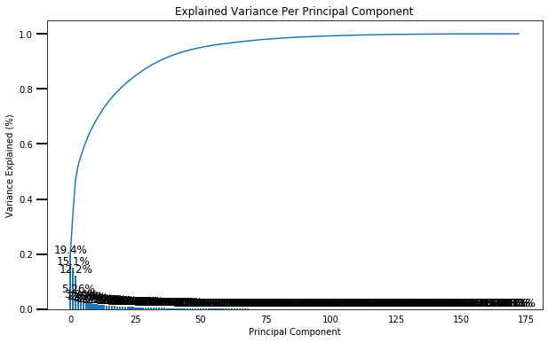

```python
# Investigate the variance accounted for by each principal component.
# code taken from: https://view3854ccca.udacity-student-workspaces.com/edit/helper_functions.py
num_components=len(pca_model.explained_variance_ratio_)
ind = np.arange(num_components)
vals = pca_model.explained_variance_ratio_

plt.figure(figsize=(10, 6))
ax = plt.subplot(111)
cumvals = np.cumsum(vals)
ax.bar(ind, vals)
ax.plot(ind, cumvals)
for i in range(num_components):
    ax.annotate(r"%s%%" % ((str(vals[i]*100)[:4])), (ind[i]+0.2, vals[i]), va="bottom", ha="center", fontsize=12)

ax.xaxis.set_tick_params(width=0)
ax.yaxis.set_tick_params(width=2, length=12)

ax.set_xlabel("Principal Component")
ax.set_ylabel("Variance Explained (%)")
plt.title('Explained Variance Per Principal Component')
```

```python
for i,v in enumerate(cumvals):
    print("Variance retained for {} Principal Components: {}%".format(i,v*100))
```

```
Variance retained for 0 Principal Components: 19.436068362721496%
Variance retained for 1 Principal Components: 34.62415638700402%
Variance retained for 2 Principal Components: 46.86090332392643%
Variance retained for 3 Principal Components: 52.12219455133981%
Variance retained for 4 Principal Components: 55.36772869881255%
Variance retained for 5 Principal Components: 58.19388376516864%
Variance retained for 6 Principal Components: 60.781913019015576%
Variance retained for 7 Principal Components: 63.17411697948718%
Variance retained for 8 Principal Components: 65.21897947462276%
Variance retained for 9 Principal Components: 67.01649292955514%
Variance retained for 10 Principal Components: 68.75713905555611%
Variance retained for 11 Principal Components: 70.30810569645418%
Variance retained for 12 Principal Components: 71.83633342538576%
Variance retained for 13 Principal Components: 73.23439587240912%
Variance retained for 14 Principal Components: 74.53193830059385%
Variance retained for 15 Principal Components: 75.78941465642721%
Variance retained for 16 Principal Components: 76.94571532284392%
Variance retained for 17 Principal Components: 78.04743134163841%
Variance retained for 18 Principal Components: 79.04859983884185%
Variance retained for 19 Principal Components: 79.97423757779957%
Variance retained for 20 Principal Components: 80.8684581121833%
Variance retained for 21 Principal Components: 81.7212942882754%
Variance retained for 22 Principal Components: 82.55027768157946%
Variance retained for 23 Principal Components: 83.3202226831253%
Variance retained for 24 Principal Components: 84.0617791487404%
Variance retained for 25 Principal Components: 84.79090144109064%
Variance retained for 26 Principal Components: 85.49044476159074%
Variance retained for 27 Principal Components: 86.15990570191587%
Variance retained for 28 Principal Components: 86.81712691512001%
Variance retained for 29 Principal Components: 87.43040714666806%
Variance retained for 30 Principal Components: 88.00975646149253%
Variance retained for 31 Principal Components: 88.58032604144029%
Variance retained for 32 Principal Components: 89.10753240069738%
Variance retained for 33 Principal Components: 89.60316754760632%
Variance retained for 34 Principal Components: 90.0717043014699%
Variance retained for 35 Principal Components: 90.52678672501993%
Variance retained for 36 Principal Components: 90.95965502842658%
Variance retained for 37 Principal Components: 91.35905703690422%
Variance retained for 38 Principal Components: 91.74440007770153%
Variance retained for 39 Principal Components: 92.11870132751707%
```

[output cut: 118 more lines]

```
Variance retained for 158 Principal Components: 100.00000000000003%
Variance retained for 159 Principal Components: 100.00000000000003%
Variance retained for 160 Principal Components: 100.00000000000003%
Variance retained for 161 Principal Components: 100.00000000000003%
Variance retained for 162 Principal Components: 100.00000000000003%
Variance retained for 163 Principal Components: 100.00000000000003%
Variance retained for 164 Principal Components: 100.00000000000003%
Variance retained for 165 Principal Components: 100.00000000000003%
Variance retained for 166 Principal Components: 100.00000000000003%
Variance retained for 167 Principal Components: 100.00000000000003%
Variance retained for 168 Principal Components: 100.00000000000003%
Variance retained for 169 Principal Components: 100.00000000000003%
Variance retained for 170 Principal Components: 100.00000000000003%
Variance retained for 171 Principal Components: 100.00000000000003%
Variance retained for 172 Principal Components: 100.00000000000003%
```

```python
for i,v in enumerate(vals):
    print("Principal Component  {} explaines: {}% of variance".format(i,v*100))
```

```
Principal Component  0 explaines: 19.436068362721496% of variance
Principal Component  1 explaines: 15.188088024282525% of variance
Principal Component  2 explaines: 12.236746936922408% of variance
Principal Component  3 explaines: 5.261291227413382% of variance
Principal Component  4 explaines: 3.245534147472741% of variance
Principal Component  5 explaines: 2.8261550663560984% of variance
Principal Component  6 explaines: 2.5880292538469383% of variance
Principal Component  7 explaines: 2.392203960471612% of variance
Principal Component  8 explaines: 2.044862495135575% of variance
Principal Component  9 explaines: 1.7975134549323761% of variance
Principal Component  10 explaines: 1.74064612600098% of variance
Principal Component  11 explaines: 1.550966640898057% of variance
Principal Component  12 explaines: 1.5282277289315809% of variance
Principal Component  13 explaines: 1.3980624470233691% of variance
Principal Component  14 explaines: 1.297542428184721% of variance
Principal Component  15 explaines: 1.2574763558333595% of variance
Principal Component  16 explaines: 1.1563006664167121% of variance
Principal Component  17 explaines: 1.1017160187944954% of variance
Principal Component  18 explaines: 1.0011684972034327% of variance
Principal Component  19 explaines: 0.9256377389577205% of variance
Principal Component  20 explaines: 0.8942205343837328% of variance
Principal Component  21 explaines: 0.852836176092099% of variance
Principal Component  22 explaines: 0.8289833933040546% of variance
Principal Component  23 explaines: 0.7699450015458424% of variance
Principal Component  24 explaines: 0.741556465615099% of variance
Principal Component  25 explaines: 0.7291222923502384% of variance
Principal Component  26 explaines: 0.6995433205000948% of variance
Principal Component  27 explaines: 0.6694609403251348% of variance
Principal Component  28 explaines: 0.6572212132041361% of variance
Principal Component  29 explaines: 0.613280231548038% of variance
Principal Component  30 explaines: 0.5793493148244749% of variance
Principal Component  31 explaines: 0.5705695799477558% of variance
Principal Component  32 explaines: 0.5272063592571085% of variance
Principal Component  33 explaines: 0.4956351469089397% of variance
Principal Component  34 explaines: 0.4685367538635706% of variance
Principal Component  35 explaines: 0.45508242355004025% of variance
Principal Component  36 explaines: 0.4328683034066558% of variance
Principal Component  37 explaines: 0.39940200847763646% of variance
Principal Component  38 explaines: 0.3853430407973191% of variance
Principal Component  39 explaines: 0.3743012498155433% of variance
```

[output cut: 118 more lines]

```
Principal Component  158 explaines: 4.590392412793858e-30% of variance
Principal Component  159 explaines: 1.4005207965385391e-30% of variance
Principal Component  160 explaines: 1.3501135722362415e-30% of variance
Principal Component  161 explaines: 1.1251081261553983e-30% of variance
Principal Component  162 explaines: 1.0740417206369785e-30% of variance
Principal Component  163 explaines: 9.363661492167145e-31% of variance
Principal Component  164 explaines: 7.181821105190906e-31% of variance
Principal Component  165 explaines: 6.181295229154476e-31% of variance
Principal Component  166 explaines: 3.801672741112453e-31% of variance
Principal Component  167 explaines: 2.143073519319038e-31% of variance
Principal Component  168 explaines: 2.0899773994114693e-31% of variance
Principal Component  169 explaines: 1.4192807425083272e-31% of variance
Principal Component  170 explaines: 1.4192807425083272e-31% of variance
Principal Component  171 explaines: 1.3229387824045415e-31% of variance
Principal Component  172 explaines: 6.110873133751672e-34% of variance
```

```python
# Re-apply PCA to the data while selecting for number of components to retain.
pca_model_50 = PCA(n_components=50)
pca_model_50.fit(df_scaled)
```

```
PCA(copy=True, iterated_power='auto', n_components=50, random_state=None,
    svd_solver='auto', tol=0.0, whiten=False)
```

### Step 2.3: Interpret Principal Components

Now that we have our transformed principal components, it's a nice idea to check out the weight of each variable on the first few components to see if they can be interpreted in some fashion.

As a reminder, each principal component is a unit vector that points in the direction of highest variance (after accounting for the variance captured by earlier principal components). The further a weight is from zero, the more the principal component is in the direction of the corresponding feature. If two features have large weights of the same sign (both positive or both negative), then increases in one tend expect to be associated with increases in the other. To contrast, features with different signs can be expected to show a negative correlation: increases in one variable should result in a decrease in the other.

- To investigate the features, you should map each weight to their corresponding feature name, then sort the features according to weight. The most interesting features for each principal component, then, will be those at the beginning and end of the sorted list. Use the data dictionary document to help you understand these most prominent features, their relationships, and what a positive or negative value on the principal component might indicate.
- You should investigate and interpret feature associations from the first three principal components in this substep. To help facilitate this, you should write a function that you can call at any time to print the sorted list of feature weights, for the *i*-th principal component. This might come in handy in the next step of the project, when you interpret the tendencies of the discovered clusters.

```python
df.columns.tolist()
```

```
['ALTERSKATEGORIE_GROB',
 'ANREDE_KZ',
 'FINANZ_MINIMALIST',
 'FINANZ_SPARER',
 'FINANZ_VORSORGER',
 'FINANZ_ANLEGER',
 'FINANZ_UNAUFFAELLIGER',
 'FINANZ_HAUSBAUER',
 'GREEN_AVANTGARDE',
 'HEALTH_TYP',
 'RETOURTYP_BK_S',
 'SEMIO_SOZ',
 'SEMIO_FAM',
 'SEMIO_REL',
 'SEMIO_MAT',
 'SEMIO_VERT',
 'SEMIO_LUST',
 'SEMIO_ERL',
 'SEMIO_KULT',
 'SEMIO_RAT',
 'SEMIO_KRIT',
 'SEMIO_DOM',
 'SEMIO_KAEM',
 'SEMIO_PFLICHT',
 'SEMIO_TRADV',
 'SOHO_KZ',
 'VERS_TYP',
 'ANZ_PERSONEN',
 'ANZ_TITEL',
 'HH_EINKOMMEN_SCORE',
 'W_KEIT_KIND_HH',
 'WOHNDAUER_2008',
 'ANZ_HAUSHALTE_AKTIV',
 'ANZ_HH_TITEL',
 'KONSUMNAEHE',
 'MIN_GEBAEUDEJAHR',
 'OST_WEST_KZ',
 'KBA05_ANTG1',
 'KBA05_ANTG2',
 'KBA05_ANTG3',
```

[output cut: 118 more lines]

```
 'CAMEO_DEU_2015_7D',
 'CAMEO_DEU_2015_7E',
 'CAMEO_DEU_2015_8A',
 'CAMEO_DEU_2015_8B',
 'CAMEO_DEU_2015_8C',
 'CAMEO_DEU_2015_8D',
 'CAMEO_DEU_2015_9A',
 'CAMEO_DEU_2015_9B',
 'CAMEO_DEU_2015_9C',
 'CAMEO_DEU_2015_9D',
 'CAMEO_DEU_2015_9E',
 'PRAEGENDE_JUGENDJAHRE_GENERATION',
 'PRAEGENDE_JUGENDJAHRE_BEWEGUNG',
 'CAMEO_INTL_2015_VERMÖGEN',
 'CAMEO_INTL_2015_LEBENSSTIL']
```

```python
# HINT: Try defining a function here or in a new cell that you can reuse in the
# other cells.
# function adapted from https://view3854ccca.udacity-student-workspaces.com/edit/helper_functions.py
def compute_weights(df, pca_model):
    features = df.columns.tolist()
    weights_per_feature = [component for component in pca_model.components_]

    weights_per_dimension_per_feature = dict()

    for i,weights in enumerate(pca_model.components_):

        weights_per_dimension_per_feature["dim {}".format(i+1)] = weights

    return weights_per_dimension_per_feature, features


weights, features = compute_weights(df_scaled, pca_model_50)
features
```

```
['ALTERSKATEGORIE_GROB',
 'ANREDE_KZ',
 'FINANZ_MINIMALIST',
 'FINANZ_SPARER',
 'FINANZ_VORSORGER',
 'FINANZ_ANLEGER',
 'FINANZ_UNAUFFAELLIGER',
 'FINANZ_HAUSBAUER',
 'GREEN_AVANTGARDE',
 'HEALTH_TYP',
 'RETOURTYP_BK_S',
 'SEMIO_SOZ',
 'SEMIO_FAM',
 'SEMIO_REL',
 'SEMIO_MAT',
 'SEMIO_VERT',
 'SEMIO_LUST',
 'SEMIO_ERL',
 'SEMIO_KULT',
 'SEMIO_RAT',
 'SEMIO_KRIT',
 'SEMIO_DOM',
 'SEMIO_KAEM',
 'SEMIO_PFLICHT',
 'SEMIO_TRADV',
 'SOHO_KZ',
 'VERS_TYP',
 'ANZ_PERSONEN',
 'ANZ_TITEL',
 'HH_EINKOMMEN_SCORE',
 'W_KEIT_KIND_HH',
 'WOHNDAUER_2008',
 'ANZ_HAUSHALTE_AKTIV',
 'ANZ_HH_TITEL',
 'KONSUMNAEHE',
 'MIN_GEBAEUDEJAHR',
 'OST_WEST_KZ',
 'KBA05_ANTG1',
 'KBA05_ANTG2',
 'KBA05_ANTG3',
```

[output cut: 118 more lines]

```
 'CAMEO_DEU_2015_7D',
 'CAMEO_DEU_2015_7E',
 'CAMEO_DEU_2015_8A',
 'CAMEO_DEU_2015_8B',
 'CAMEO_DEU_2015_8C',
 'CAMEO_DEU_2015_8D',
 'CAMEO_DEU_2015_9A',
 'CAMEO_DEU_2015_9B',
 'CAMEO_DEU_2015_9C',
 'CAMEO_DEU_2015_9D',
 'CAMEO_DEU_2015_9E',
 'PRAEGENDE_JUGENDJAHRE_GENERATION',
 'PRAEGENDE_JUGENDJAHRE_BEWEGUNG',
 'CAMEO_INTL_2015_VERMÖGEN',
 'CAMEO_INTL_2015_LEBENSSTIL']
```

```python
def plot_weights(weights, features, dim):
    weights = weights["dim {}".format(dim)]

    weights_per_feature_dict = dict()

    for i,f in enumerate(features):
        weights_per_feature_dict[f] = weights[i]

    weights_per_feature = sorted(weights_per_feature_dict.items(),key=lambda x: x[1], reverse=True)

    x= [x for x,y in weights_per_feature]
    y= [y for x,y in weights_per_feature]

    plt.figure(figsize=(30,50))
    sns.barplot(y,x)
    plt.title("Dimension of PC {}".format(dim))
    plt.xlabel("Feature Name")
    plt.ylabel("Weight")
    plt.show()

    return weights_per_feature
```

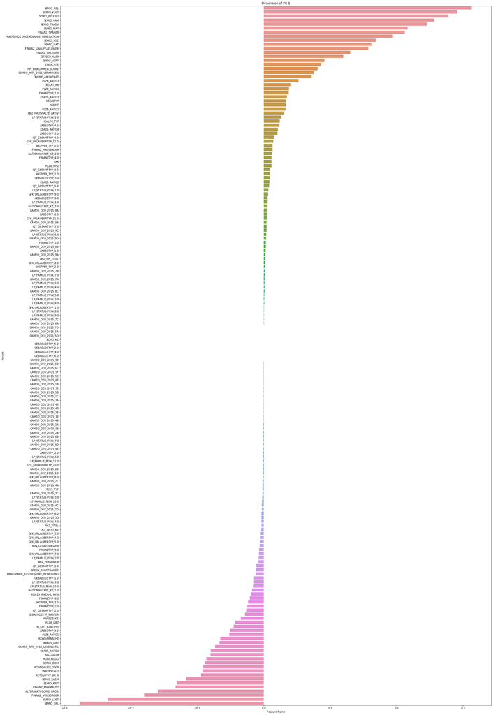

```python
# Map weights for the first principal component to corresponding feature names
# and then print the linked values, sorted by weight.
weights_1 = plot_weights(weights, features, 1)
```

```python
weights_1[:5]
```

```
[('SEMIO_REL', 0.31319172517819094),
 ('SEMIO_KULT', 0.29130754322496877),
 ('SEMIO_PFLICHT', 0.2784395663627241),
 ('SEMIO_FAM', 0.25682271963853665),
 ('SEMIO_TRADV', 0.24527331933055432)]
```

```python
weights_1[-5:]
```

```
[('FINANZ_MINIMALIST', -0.13294157372494345),
 ('ALTERSKATEGORIE_GROB', -0.15972647811141924),
 ('FINANZ_VORSORGER', -0.180154779211836),
 ('SEMIO_LUST', -0.23504303373187865),
 ('SEMIO_ERL', -0.276529924487803)]
```

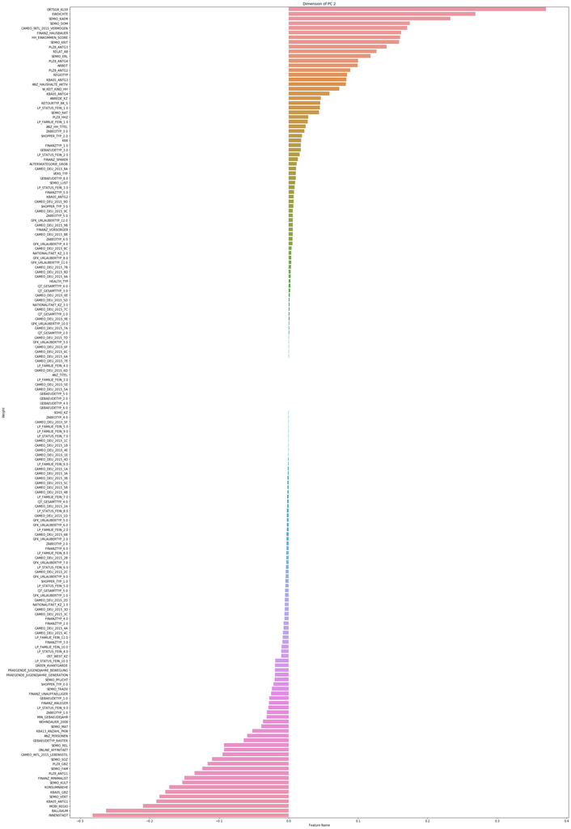

```python
# Map weights for the second principal component to corresponding feature names
# and then print the linked values, sorted by weight.
weights_2 = plot_weights(weights, features, 2)
```

```python
weights_2[:5]
```

```
[('ORTSGR_KLS9', 0.37043986312695554),
 ('EWDICHTE', 0.2686626534907056),
 ('SEMIO_KAEM', 0.2327530077230031),
 ('SEMIO_DOM', 0.174488274955938),
 ('CAMEO_INTL_2015_VERMÖGEN', 0.17079511237349562)]
```

```python
weights_2[-5:]
```

```
[('SEMIO_VERT', -0.18595233393314628),
 ('KBA05_ANTG1', -0.19009729404967063),
 ('MOBI_REGIO', -0.2094596577253927),
 ('BALLRAUM', -0.26288298324003273),
 ('INNENSTADT', -0.28184441973027846)]
```

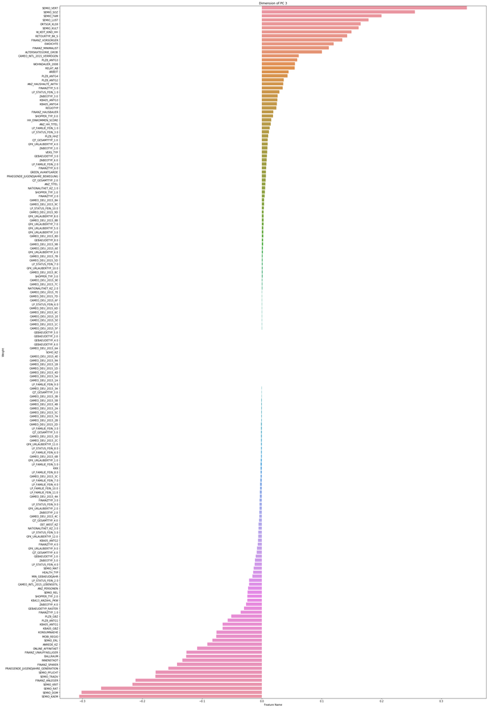

```python
# Map weights for the third principal component to corresponding feature names
# and then print the linked values, sorted by weight.
weights_3 = plot_weights(weights, features, 3)
```

```python
weights_3[:5]
```

```
[('SEMIO_VERT', 0.3427840232688224),
 ('SEMIO_SOZ', 0.2557733827419531),
 ('SEMIO_FAM', 0.19980846740150937),
 ('SEMIO_LUST', 0.17823841763886109),
 ('ORTSGR_KLS9', 0.16503794095528163)]
```

```python
weights_3[-5:]
```

```
[('FINANZ_ANLEGER', -0.211556569910511),
 ('SEMIO_KRIT', -0.2166924961201345),
 ('SEMIO_RAT', -0.26910535824411497),
 ('SEMIO_DOM', -0.30177497968352773),
 ('SEMIO_KAEM', -0.30554274376119944)]
```

### Discussion 2.3: Interpret Principal Components

#### Top 5 Positive Weights for PC 1

- ('SEMIO_REL', 0.31319172517748256): personality typology religious
- ('SEMIO_KULT', 0.29130754322632746): personality typology cultural-minded
- ('SEMIO_PFLICHT', 0.27843956636235828): personality typology dutiful
- ('SEMIO_FAM', 0.25682271963842596): personality typology family-mindes
- ('SEMIO_TRADV', 0.24527331933087262) personality typology traditional-minded

#### Top 5 Negative Weights for PC 1

- ('FINANZ_MINIMALIST', -0.13294157372452448): financial typology low financial interest
- ('ALTERSKATEGORIE_GROB', -0.15972647811424093):
- ('FINANZ_VORSORGER', -0.18015477921035816): financial typology be prepared
- ('SEMIO_LUST', -0.2350430337318449): personality typology sensual-minded
- ('SEMIO_ERL', -0.2765299244865671): personality typology event-oriented

The first principal component seems to describe personality traded with respect to cultural (religion, tradition etc.) / financial aspects. One interesting finding is that the personality components seem to lay on an opposite scale (event-oriented, sensual --> affective vs. religious, cultural, dutiful --> orderly, which would reflect personality traits that are described in psychology as the Big 5.

#### Top 5 Positive Weights for PC 2

- ('ORTSGR_KLS9', 0.37043986312641491): Size of community
- ('EWDICHTE', 0.26866265349223151): Density of households per square kilometer
- ('SEMIO_KAEM', 0.23275300772136709): personality typology combative attitud
- ('SEMIO_DOM', 0.17448827495562774): personality typology dominant-minded
- ('CAMEO_INTL_2015_VERMÖGEN', 0.17079511237377662): Wealth

#### Top 5 Negative Weights for PC 2

- ('SEMIO_VERT', -0.18595233393360761): personality typology dreamful
- ('KBA05_ANTG1', -0.19009729405128503): Number of 1-2 family houses in the microcell
- ('MOBI_REGIO', -0.20945965772420053): Movement patterns
- ('BALLRAUM', -0.26288298324018383): Distance to nearest urban center
- ('INNENSTADT', -0.28184441973037655): Distance to city center (downtown)

The second principal component is mostly comprised of features with respect to local / regional information (community size, household density, movement, patterns, distance to city/urban centers). Additionally the positive weights also consists of competititve personal traits (dominance and competiveness) as well as wealth, which could be relatable to a person's socio-econimic status.

#### Top 5 Positive Weights for PC 3

  #### Top 5 Negative Weights for PC 3
- ('FINANZ_ANLEGER', -0.2115565698977136): financial typology investor
- ('SEMIO_KRIT', -0.21669249611955255): personality typology critical-minded
- ('SEMIO_RAT', -0.26910535824574627): personality typology rational
- ('SEMIO_DOM', -0.30177497968093708): personality typology dominant-minded
- ('SEMIO_KAEM', -0.30554274375896501): personality typology combative attitude

## Step 3: Clustering

### Step 3.1: Apply Clustering to General Population

You've assessed and cleaned the demographics data, then scaled and transformed them. Now, it's time to see how the data clusters in the principal components space. In this substep, you will apply k-means clustering to the dataset and use the average within-cluster distances from each point to their assigned cluster's centroid to decide on a number of clusters to keep.

- Use sklearn's KMeans class to perform k-means clustering on the PCA-transformed data.
- Then, compute the average difference from each point to its assigned cluster's center. **Hint**: The KMeans object's `.score()` method might be useful here, but note that in sklearn, scores tend to be defined so that larger is better. Try applying it to a small, toy dataset, or use an internet search to help your understanding.
- Perform the above two steps for a number of different cluster counts. You can then see how the average distance decreases with an increasing number of clusters. However, each additional cluster provides a smaller net benefit. Use this fact to select a final number of clusters in which to group the data. **Warning**: because of the large size of the dataset, it can take a long time for the algorithm to resolve. The more clusters to fit, the longer the algorithm will take. You should test for cluster counts through at least 10 clusters to get the full picture, but you shouldn't need to test for a number of clusters above about 30.
- Once you've selected a final number of clusters to use, re-fit a KMeans instance to perform the clustering operation. Make sure that you also obtain the cluster assignments for the general demographics data, since you'll be using them in the final Step 3.3.

```python
from sklearn.cluster import KMeans
transformed_data = pca_model_50.transform(df_scaled)
```

```python
scores = []
kmeans_model = []

k_range = range(2,21)


# Over a number of different cluster counts...
for k in k_range:
    # run k-means clustering on the data and...
    model=KMeans(k).fit(transformed_data)
    kmeans_model.append(model)

    # compute the average within-cluster distances.
    score=model.score(transformed_data)
    scores.append(score)

    print("Trained k means model for k = {}".format(k))
```

```
Trained k means model for k = 2
Trained k means model for k = 3
Trained k means model for k = 4
Trained k means model for k = 5
Trained k means model for k = 6
Trained k means model for k = 7
Trained k means model for k = 8
Trained k means model for k = 9
Trained k means model for k = 10
Trained k means model for k = 11
Trained k means model for k = 12
Trained k means model for k = 13
Trained k means model for k = 14
Trained k means model for k = 15
Trained k means model for k = 16
Trained k means model for k = 17
Trained k means model for k = 18
Trained k means model for k = 19
Trained k means model for k = 20
```

```python
scores_corrected = list(map(abs, scores))
```

[output not shown]

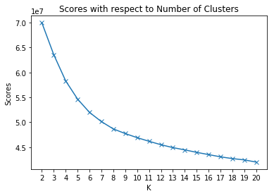

```python
list_k_range = list(k_range)

# Investigate the change in within-cluster distance across number of clusters.
# HINT: Use matplotlib's plot function to visualize this relationship.
plt.plot(list_k_range, scores_corrected, marker="x")
plt.title("Scores with respect to Number of Clusters")
plt.xlabel("K")
plt.xticks(list_k_range)
plt.ylabel("Scores")
```

Using the elbow technique, a k value of 7 clusters seems to be appropriate for the given data.

```python
# Re-fit the k-means model with the selected number of clusters and obtain
# cluster predictions for the general population demographics data.
k_means_7 = KMeans(7)
k_means_7.fit(transformed_data)
```

```
KMeans(algorithm='auto', copy_x=True, init='k-means++', max_iter=300,
       n_clusters=7, n_init=10, n_jobs=None, precompute_distances='auto',
       random_state=None, tol=0.0001, verbose=0)
```

### Discussion 3.1: Apply Clustering to General Population

I have used 7 clusters as an optimal values for k.

### Step 3.2: Apply All Steps to the Customer Data

Now that you have clusters and cluster centers for the general population, it's time to see how the customer data maps on to those clusters. Take care to not confuse this for re-fitting all of the models to the customer data. Instead, you're going to use the fits from the general population to clean, transform, and cluster the customer data. In the last step of the project, you will interpret how the general population fits apply to the customer data.

- Don't forget when loading in the customers data, that it is semicolon (`;`) delimited.
- Apply the same feature wrangling, selection, and engineering steps to the customer demographics using the `clean_data()` function you created earlier. (You can assume that the customer demographics data has similar meaning behind missing data patterns as the general demographics data.)
- Use the sklearn objects from the general demographics data, and apply their transformations to the customers data. That is, you should not be using a `.fit()` or `.fit_transform()` method to re-fit the old objects, nor should you be creating new sklearn objects! Carry the data through the feature scaling, PCA, and clustering steps, obtaining cluster assignments for all of the data in the customer demographics data.

```python
# Load in the customer demographics data.
customers = pd.read_csv("Udacity_CUSTOMERS_Subset.csv",sep=";")
```

```python
# Apply preprocessing, feature transformation, and clustering from the general
# demographics onto the customer data, obtaining cluster predictions for the
# customer demographics data.
customers_copy = deepcopy(customers)
customers_cleaned = remove_nan(clean_data(customers_copy))
customers_cleaned.head()
```

|  | ALTERSKATEGORIE_GROB | ANREDE_KZ | FINANZ_MINIMALIST | FINANZ_SPARER | FINANZ_VORSORGER | FINANZ_ANLEGER | FINANZ_UNAUFFAELLIGER | FINANZ_HAUSBAUER | GREEN_AVANTGARDE | HEALTH_TYP | ... | CAMEO_DEU_2015_8D | CAMEO_DEU_2015_9A | CAMEO_DEU_2015_9B | CAMEO_DEU_2015_9C | CAMEO_DEU_2015_9D | CAMEO_DEU_2015_9E | PRAEGENDE_JUGENDJAHRE_GENERATION | PRAEGENDE_JUGENDJAHRE_BEWEGUNG | CAMEO_INTL_2015_VERMÖGEN | CAMEO_INTL_2015_LEBENSSTIL |
| --- | --- | --- | --- | --- | --- | --- | --- | --- | --- | --- | --- | --- | --- | --- | --- | --- | --- | --- | --- | --- | --- |
| 0 | 4.0 | 1 | 5 | 1 | 5 | 1 | 2 | 2 | 1 | 1.0 | ... | 0 | 0 | 0 | 0 | 0 | 0 | 2.0 | 1.0 | 1.0 | 3.0 |
| 2 | 4.0 | 2 | 5 | 1 | 5 | 1 | 4 | 4 | 1 | 2.0 | ... | 0 | 0 | 0 | 0 | 0 | 0 | 2.0 | 1.0 | 3.0 | 4.0 |
| 4 | 3.0 | 1 | 3 | 1 | 4 | 4 | 5 | 2 | 0 | 3.0 | ... | 0 | 0 | 0 | 0 | 0 | 0 | 4.0 | 0.0 | 4.0 | 1.0 |
| 5 | 3.0 | 1 | 5 | 1 | 5 | 1 | 2 | 3 | 1 | 3.0 | ... | 0 | 0 | 0 | 0 | 0 | 0 | 2.0 | 1.0 | 3.0 | 4.0 |
| 6 | 4.0 | 1 | 5 | 1 | 5 | 1 | 1 | 2 | 1 | 2.0 | ... | 0 | 0 | 0 | 0 | 0 | 0 | 2.0 | 1.0 | 2.0 | 3.0 |

5 rows × 172 columns

```python
# scale numeric features
customers_scaled = deepcopy(customers_cleaned)
for col in scaler_dict.keys():
    customers_scaled[col] = scaler_dict[col].transform(np.array(customers_scaled[col]).reshape(-1,1))
customers_scaled["ANZ_PERSONEN"]
```

```
0         0.170632
2        -0.719121
4         1.950138
5         0.170632
6         0.170632
            ...
191646   -0.719121
191647   -0.719121
191649    1.060385
191650    1.950138
191651    1.060385
Name: ANZ_PERSONEN, Length: 115643, dtype: float64
```

```python
set(df_scaled.columns)-set(customers_scaled.columns)
```

```
{'GEBAEUDETYP_5.0'}
```

```python
customers[customers["GEBAEUDETYP"] == 5.0]
```

|  | AGER_TYP | ALTERSKATEGORIE_GROB | ANREDE_KZ | CJT_GESAMTTYP | FINANZ_MINIMALIST | FINANZ_SPARER | FINANZ_VORSORGER | FINANZ_ANLEGER | FINANZ_UNAUFFAELLIGER | FINANZ_HAUSBAUER | ... | PLZ8_ANTG1 | PLZ8_ANTG2 | PLZ8_ANTG3 | PLZ8_ANTG4 | PLZ8_BAUMAX | PLZ8_HHZ | PLZ8_GBZ | ARBEIT | ORTSGR_KLS9 | RELAT_AB |
| --- | --- | --- | --- | --- | --- | --- | --- | --- | --- | --- | --- | --- | --- | --- | --- | --- | --- | --- | --- | --- | --- |

0 rows × 85 columns

```python
# as the colum was removed during data preprocessing, re-add col with zero values to conform for 173 features of k means model
customers_scaled['GEBAEUDETYP_5.0'] = np.zeros(len(customers_scaled))
```

### Step 3.3: Compare Customer Data to Demographics Data

At this point, you have clustered data based on demographics of the general population of Germany, and seen how the customer data for a mail-order sales company maps onto those demographic clusters. In this final substep, you will compare the two cluster distributions to see where the strongest customer base for the company is.

Consider the proportion of persons in each cluster for the general population, and the proportions for the customers. If we think the company's customer base to be universal, then the cluster assignment proportions should be fairly similar between the two. If there are only particular segments of the population that are interested in the company's products, then we should see a mismatch from one to the other. If there is a higher proportion of persons in a cluster for the customer data compared to the general population (e.g. 5% of persons are assigned to a cluster for the general population, but 15% of the customer data is closest to that cluster's centroid) then that suggests the people in that cluster to be a target audience for the company. On the other hand, the proportion of the data in a cluster being larger in the general population than the customer data (e.g. only 2% of customers closest to a population centroid that captures 6% of the data) suggests that group of persons to be outside of the target demographics.

Take a look at the following points in this step:

- Compute the proportion of data points in each cluster for the general population and the customer data. Visualizations will be useful here: both for the individual dataset proportions, but also to visualize the ratios in cluster representation between groups. Seaborn's [`countplot()`](https://seaborn.pydata.org/generated/seaborn.countplot.html) or [`barplot()`](https://seaborn.pydata.org/generated/seaborn.barplot.html) function could be handy.
  - Recall the analysis you performed in step 1.1.3 of the project, where you separated out certain data points from the dataset if they had more than a specified threshold of missing values. If you found that this group was qualitatively different from the main bulk of the data, you should treat this as an additional data cluster in this analysis. Make sure that you account for the number of data points in this subset, for both the general population and customer datasets, when making your computations!
- Which cluster or clusters are overrepresented in the customer dataset compared to the general population? Select at least one such cluster and infer what kind of people might be represented by that cluster. Use the principal component interpretations from step 2.3 or look at additional components to help you make this inference. Alternatively, you can use the `.inverse_transform()` method of the PCA and StandardScaler objects to transform centroids back to the original data space and interpret the retrieved values directly.
- Perform a similar investigation for the underrepresented clusters. Which cluster or clusters are underrepresented in the customer dataset compared to the general population, and what kinds of people are typified by these clusters?

```python
# Compare the proportion of data in each cluster for the customer data to the
# proportion of data in each cluster for the general population.
cluster_pop = k_means_7.predict(transformed_data)
cluster_custom = k_means_7.predict(pca_model_50.transform(customers_scaled))
```

```python
cluster_custom
```

```
array([2, 5, 1, ..., 2, 5, 2])
```

```python
cluster_pop
```

```
array([6, 0, 1, ..., 4, 3, 2])
```

```python
cluster_pop_dict=dict()
cluster_custom_dict=dict()
```

```python
cluster_indices = list(range(len(k_means_7.cluster_centers_)))
cluster_indices
```

```
[0, 1, 2, 3, 4, 5, 6]
```

```python
for i in cluster_indices:
    cluster_pop_dict[i] = len(cluster_pop[cluster_pop == i])
    cluster_custom_dict[i] = len(cluster_custom[cluster_custom == i])
```

```python
cluster_pop_dict
```

```
{0: 107359, 1: 95559, 2: 115282, 3: 92170, 4: 58774, 5: 93175, 6: 60892}
```

```python
cluster_custom_dict
```

```
{0: 20071, 1: 21357, 2: 54530, 3: 2353, 4: 1141, 5: 14568, 6: 1623}
```

```python
x_pop = [x for x,y in cluster_pop_dict.items()]
y_pop = [y for x,y in cluster_pop_dict.items()]

x_custom = [x for x,y in cluster_custom_dict.items()]
y_custom = [y for x,y in cluster_custom_dict.items()]
```

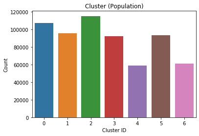

```python
plt.title("Cluster (Population)")
plt.xlabel("Cluster ID")
plt.ylabel("Count")
sns.barplot(x_pop,y_pop)
```

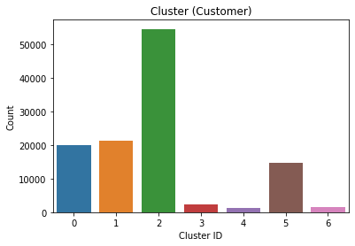

```python
plt.title("Cluster (Customer)")
plt.xlabel("Cluster ID")
plt.ylabel("Count")
sns.barplot(x_custom,y_custom)
```

```python
scaler_dict
```

```
{'ANZ_PERSONEN': StandardScaler(copy=True, with_mean=True, with_std=True),
 'ANZ_TITEL': StandardScaler(copy=True, with_mean=True, with_std=True),
 'ANZ_HAUSHALTE_AKTIV': StandardScaler(copy=True, with_mean=True, with_std=True),
 'ANZ_HH_TITEL': StandardScaler(copy=True, with_mean=True, with_std=True),
 'MIN_GEBAEUDEJAHR': StandardScaler(copy=True, with_mean=True, with_std=True),
 'KBA13_ANZAHL_PKW': StandardScaler(copy=True, with_mean=True, with_std=True)}
```

```python
len(transformed_data)
```

```
623211
```

```python
len(cluster_pop)
```

```
623211
```

```python
customer_transformed = pca_model_50.transform(customers_scaled)
len(customer_transformed)
```

```
115643
```

```python
len(cluster_custom)
```

```
115643
```

```python
# What kinds of people are part of a cluster that is overrepresented in the
# customer data compared to the general population?

# The cluster with id 2 seems to be overrepresented in the customer data
# compared to the general population data

customer_transformed_copy =customer_transformed.copy()

custom_to_original_2 = pca_model_50.inverse_transform(customer_transformed_copy[cluster_custom == 2])
custom_to_original_2 = pd.DataFrame(custom_to_original_2)
```

```python
custom_to_original_2.columns = customers_scaled.columns
```

```python
custom_to_original_2.head()
```

|  | ALTERSKATEGORIE_GROB | ANREDE_KZ | FINANZ_MINIMALIST | FINANZ_SPARER | FINANZ_VORSORGER | FINANZ_ANLEGER | FINANZ_UNAUFFAELLIGER | FINANZ_HAUSBAUER | GREEN_AVANTGARDE | HEALTH_TYP | ... | CAMEO_DEU_2015_9A | CAMEO_DEU_2015_9B | CAMEO_DEU_2015_9C | CAMEO_DEU_2015_9D | CAMEO_DEU_2015_9E | PRAEGENDE_JUGENDJAHRE_GENERATION | PRAEGENDE_JUGENDJAHRE_BEWEGUNG | CAMEO_INTL_2015_VERMÖGEN | CAMEO_INTL_2015_LEBENSSTIL | GEBAEUDETYP_5.0 |
| --- | --- | --- | --- | --- | --- | --- | --- | --- | --- | --- | --- | --- | --- | --- | --- | --- | --- | --- | --- | --- | --- |
| 0 | 4.270972 | 0.969329 | 5.164324 | 1.138772 | 5.057385 | 1.047148 | 2.075360 | 2.188382 | 0.851479 | 0.980295 | ... | -0.099777 | 0.010758 | 0.045122 | 0.060163 | 0.039412 | -0.008421 | 1.000879 | 0.851479 | 3.040291 | 0.083840 |
| 1 | 3.346285 | 0.966874 | 4.872864 | 1.040370 | 5.263021 | 0.780654 | 2.126325 | 2.907896 | 1.094030 | 3.137512 | ... | -0.063506 | 0.064340 | 0.105434 | 0.060577 | 0.046065 | -0.013623 | 1.369865 | 1.094030 | 4.010448 | 0.086013 |
| 2 | 3.223885 | 1.179245 | 5.136229 | 0.914931 | 5.288876 | 1.080340 | 1.289113 | 2.016862 | 0.714865 | 1.685544 | ... | -0.098144 | 0.015596 | 0.062943 | 0.066107 | 0.054061 | -0.015566 | 1.047431 | 0.714865 | 3.108661 | 0.077010 |
| 3 | 4.101200 | 0.931321 | 5.210247 | 1.152595 | 5.078577 | 1.067852 | 2.088754 | 2.140281 | 1.000868 | 0.953515 | ... | -0.028771 | 0.036897 | 0.078457 | 0.088172 | 0.082728 | 0.004662 | 0.915206 | 1.000868 | 4.997902 | 0.081988 |
| 4 | 3.290976 | 1.000517 | 4.827527 | 1.948906 | 4.300322 | 0.881703 | 2.987296 | 0.886033 | 0.973932 | 3.098054 | ... | -0.039328 | 0.065392 | 0.057180 | 0.062908 | 0.085220 | 0.007085 | 1.404485 | 0.973932 | 4.980451 | 0.068748 |

5 rows × 173 columns